# Repetition study

Aitor San Jose, Mits Ota, Kenny Smith

23 October 2019

# 1 Preamble

These are GCA analyses and model comparisons run for the reduplication study. Originally in raw R script, now in R Notebook format. It saves tables as .doc files and plots as .pdf files. *This one uses the new coding of phonological repeition implemented by Kenny*.

# 2 Packages

```r
library(ggplot2)
library(broom)
library(lme4)
library(bbmle)
library(lmerTest)
library(sjPlot)
library(plyr)
library(reshape2)
```

# 3 Data preparation

## 3.1 Data read-in

This reads in the new dataset that includes the new coding of syllable and consonant repetition. It then runs Kenny’s code that identifies vowel repetition.

```r
df = read.table(file="data_june_2018_recoded2.csv", na.strings=c("", "NA"), sep=",", header=TRUE)
#function that spots repetitions of adjacent vowels
vowel.repetition <- function(l) {
  no.consonant.l <- stringr::str_replace_all(l,"([^a^e^i^o^u])", '') #remove consonants
  ifelse(grepl('.*(\\D)\\1.*',no.consonant.l),1,0) #then check for adjacent identical characters
}
#use slightly different fields dependiong on trial type
score.vowel.repetition <- function(stage,training.label,typed.label) {
  if (stage=='vocabTraining')
    vowel.repetition(training.label)
  else if (stage=='interactD')
    vowel.repetition(typed.label)
  else {NA}
}
df$VowelRepetition <- mapply(function(s,trainl,testl) score.vowel.repetition(s,trainl,testl),
                                   df$Stage,
                                   df$TrainingLabel,
                                   df$TypedLabel)
colnames(df)[6] <- "Unique_language"
df$CandV = ifelse(df$ConsonantRepetition == 1 & df$VowelRepetition == 1, 1, 0)
df$CorV = ifelse(df$ConsonantRepetition == 1 | df$VowelRepetition == 1, 1, 0)
df$Trial_Iteration[is.na(df$Trial_Iteration)] <- 0 #make NAs 0 for next line to work
df.all = df  # this dataframe keeps data from the seed, and both the FIRST and SECOND rounds of iterations.
df <-subset(df,Trial_Iteration != 1)  # keep seed languages and second round of iterations
# df <- subset(df, Transmitter == 1) # uncomment to keep only the data from the participants whose language was used to train the following generation
df_director<-subset(df,Stage!='interactM') # includes seed languages
df_director<-subset(df.all, Trial_Iteration != 2 & Stage!='interactM') # uncomment to switch to using Iteration 1 data
df_matcher<-subset(df,Stage=='interactM') # includes only generations 1 to 5, since there is no accuracy for seed languages
df_director_generations_1_to_5 <- subset(df_director, Generation > 0) #excludes seed languages
```

## 3.2 Sum-coding

```r
contrasts(df_director$LexiconType) = contr.sum(2)
contrasts(df_director$GroupType) = contr.sum(2)
contrasts(df_matcher$LexiconType) = contr.sum(2)
contrasts(df_matcher$GroupType) = contr.sum(2)
```

## 3.3 Adding 3rd-order polynomials for GCA

```r
df_director$timebin = df_director$Generation + 1
t = poly(unique(df_director$timebin), 3)
df_director[,paste("ot", 1:3, sep="")] <- t[df_director$timebin, 1:3]
df_matcher$timebin = df_matcher$Generation
t = poly(unique(df_matcher$timebin), 3)
df_matcher[,paste("ot", 1:3, sep="")] <- t[df_matcher$timebin, 1:3]
```

# 4 The effect of repetition on learning (as measured by distance between seed words and first reproductions)

## 4.1 Calculation of edit distance

This calculate the edit distance between the training (seed) word and the typed word for the same object. It also collects info about C, V and syllable repetition and the orthographic length of the seed word.

```r
SeedLabel = unique(ddply(df_director[df_director$Stage == "vocabTraining", ], c("GroupNumber", "GroupType", "LexiconType", "Meaning"), summarise, Seed = as.character(TrainingLabel), SeedRepC = as.integer(ConsonantRepetition), SeedRepV = as.integer(VowelRepetition), SeedRepSyl = as.integer(SyllableRepetition), SeedCandV = as.integer(CandV), SeedCorV = as.integer(CorV)))
df.all_director_1_5<-subset(df.all, Stage !='interactM' & Generation != 0) # this df only contains the director's production in Gen 1-5
df_learning = merge(df.all_director_1_5, SeedLabel, all.x = TRUE)
normdist <- function(x,y) {
  stringdist::stringdist(x,y,method="lv")/max(nchar(x),nchar(y))
}
df_learning$dist = mapply(normdist, as.character(df_learning$Seed), as.character(df_learning$TypedLabel))
df_learning$SeedLength = nchar(as.character(df_learning$Seed))
```

## 4.2 LME analysis of edit distance (by length, repetition and lexicon size)

This analysis looks at the edit distance between the seed words and the participants’ very first productions (i.e., the first pass of the first generation/round). The factors considered are: consonant, vowel and syllable repetition in the seed word (SeedRepC, SeedRepV and SeedRepS, respectively), consonantANDvowel repetition, consonantORvowel repetition, length of the seed word (sSeedLength, which is scaled) and lexicon size (LexiconType). Separate analyses were run for C, V, S, C&V and C|V repetitions as they are strongly correlated with each due to the fact that the unit of repetition in the seedwords was CV. The strongest effect comes from the length of the seed word; shorter seed words are more faithfully reproduced than longer ones. But there is also an independent effect of consonant repetition; seed words that contains a repetition are more faithfullly reproduced than those without repetitions. No effects of V repetition, S repetition, C&V repetition or C|V repetition. Interestingly there is no effect of lexicon size, although there’s some indication of a three-way interaction between length x repetition x lexicon size.

```r
df_learning_first = subset(df_learning, Generation == 1 & Trial_Iteration == 1)
df_learning_first$sSeedLength = scale(df_learning_first$SeedLength)
learning_RepC = lmer(dist ~ LexiconType*SeedRepC*sSeedLength + (1|Unique_Participant) + (1|Meaning), data=df_learning_first, control=lmerControl(optimizer = "bobyqa", optCtrl=list(maxfun=1e5)), REML=FALSE)
learning_RepV = lmer(dist ~ LexiconType*SeedRepV*sSeedLength + (1|Unique_Participant) + (1|Meaning), data=df_learning_first, control=lmerControl(optimizer = "bobyqa", optCtrl=list(maxfun=1e5)), REML=FALSE)
learning_RepS = lmer(dist ~ LexiconType*SeedRepSyl*sSeedLength + (1|Unique_Participant) + (1|Meaning), data=df_learning_first, control=lmerControl(optimizer = "bobyqa", optCtrl=list(maxfun=1e5)), REML=FALSE)
learning_CandV = lmer(dist ~ LexiconType*SeedCandV*sSeedLength + (1|Unique_Participant) + (1|Meaning), data=df_learning_first, control=lmerControl(optimizer = "bobyqa", optCtrl=list(maxfun=1e5)), REML=FALSE)
learning_CorV = lmer(dist ~ LexiconType*SeedCorV*sSeedLength + (1|Unique_Participant) + (1|Meaning), data=df_learning_first, control=lmerControl(optimizer = "bobyqa", optCtrl=list(maxfun=1e5)), REML=FALSE)
summary(learning_RepC)
```

```
Linear mixed model fit by maximum likelihood . t-tests use Satterthwaite's method [
lmerModLmerTest]
Formula: dist ~ LexiconType * SeedRepC * sSeedLength + (1 | Unique_Participant) +
    (1 | Meaning)
   Data: df_learning_first
Control: lmerControl(optimizer = "bobyqa", optCtrl = list(maxfun = 1e+05))

     AIC      BIC   logLik deviance df.resid
   328.5    378.8   -153.2    306.5      707

Scaled residuals:
    Min      1Q  Median      3Q     Max
-2.1381 -0.7183 -0.2033  0.7365  3.0028

Random effects:
 Groups             Name        Variance  Std.Dev.
 Unique_Participant (Intercept) 0.0233943 0.15295
 Meaning            (Intercept) 0.0007019 0.02649
 Residual                       0.0796693 0.28226
Number of obs: 718, groups:  Unique_Participant, 48; Meaning, 18

Fixed effects:
                                        Estimate Std. Error         df t value
(Intercept)                            3.638e-01  3.610e-02  5.527e+01  10.077
LexiconTypesmall                       6.184e-05  5.152e-02  5.965e+01   0.001
SeedRepC                              -7.156e-02  3.280e-02  6.960e+02  -2.182
sSeedLength                            6.856e-02  1.674e-02  6.705e+02   4.096
LexiconTypesmall:SeedRepC             -1.429e-03  5.078e-02  6.906e+02  -0.028
LexiconTypesmall:sSeedLength           3.392e-02  2.648e-02  6.784e+02   1.281
SeedRepC:sSeedLength                   4.954e-02  3.154e-02  6.528e+02   1.571
LexiconTypesmall:SeedRepC:sSeedLength -7.126e-02  5.302e-02  6.827e+02  -1.344
                                      Pr(>|t|)
(Intercept)                           4.01e-14 ***
LexiconTypesmall                        0.9990
SeedRepC                                0.0295 *
sSeedLength                           4.72e-05 ***
LexiconTypesmall:SeedRepC               0.9776
LexiconTypesmall:sSeedLength            0.2007
SeedRepC:sSeedLength                    0.1168
LexiconTypesmall:SeedRepC:sSeedLength   0.1794
---
Signif. codes:  0 ‘***’ 0.001 ‘**’ 0.01 ‘*’ 0.05 ‘.’ 0.1 ‘ ’ 1

Correlation of Fixed Effects:
            (Intr) LxcnTy SedRpC sSdLng LxT:SRC LxT:SL SRC:SL
LxcnTypsmll -0.680
SeedRepC    -0.263  0.184
sSeedLength  0.069 -0.045 -0.081
LxcnTyp:SRC  0.170 -0.278 -0.644  0.052
LxcnTyps:SL -0.044  0.075  0.050 -0.631 -0.081
SdRpC:sSdLn -0.034  0.025 -0.245 -0.545  0.154   0.346
LxcT:SRC:SL  0.021 -0.040  0.144  0.327 -0.147  -0.518 -0.596
```

```r
summary(learning_RepV)
```

```
Linear mixed model fit by maximum likelihood . t-tests use Satterthwaite's method [
lmerModLmerTest]
Formula: dist ~ LexiconType * SeedRepV * sSeedLength + (1 | Unique_Participant) +
    (1 | Meaning)
   Data: df_learning_first
Control: lmerControl(optimizer = "bobyqa", optCtrl = list(maxfun = 1e+05))

     AIC      BIC   logLik deviance df.resid
   335.4    385.7   -156.7    313.4      707

Scaled residuals:
    Min      1Q  Median      3Q     Max
-2.1693 -0.6992 -0.1836  0.7387  3.0571

Random effects:
 Groups             Name        Variance  Std.Dev.
 Unique_Participant (Intercept) 0.0233119 0.15268
 Meaning            (Intercept) 0.0005973 0.02444
 Residual                       0.0805817 0.28387
Number of obs: 718, groups:  Unique_Participant, 48; Meaning, 18

Fixed effects:
                                        Estimate Std. Error         df t value
(Intercept)                             0.343593   0.037078  61.882515   9.267
LexiconTypesmall                       -0.005308   0.053937  71.688713  -0.098
SeedRepV                                0.002906   0.030619 680.086735   0.095
sSeedLength                             0.070902   0.018762 676.753663   3.779
LexiconTypesmall:SeedRepV              -0.024843   0.049075 680.887147  -0.506
LexiconTypesmall:sSeedLength           -0.000686   0.031172 681.579131  -0.022
SeedRepV:sSeedLength                    0.011441   0.030704 681.721098   0.373
LexiconTypesmall:SeedRepV:sSeedLength   0.055921   0.052041 695.749706   1.075
                                      Pr(>|t|)
(Intercept)                           2.65e-13 ***
LexiconTypesmall                      0.921878
SeedRepV                              0.924417
sSeedLength                           0.000171 ***
LexiconTypesmall:SeedRepV             0.612861
LexiconTypesmall:sSeedLength          0.982449
SeedRepV:sSeedLength                  0.709557
LexiconTypesmall:SeedRepV:sSeedLength 0.282949
---
Signif. codes:  0 ‘***’ 0.001 ‘**’ 0.01 ‘*’ 0.05 ‘.’ 0.1 ‘ ’ 1

Correlation of Fixed Effects:
            (Intr) LxcnTy SedRpV sSdLng LxT:SRV LxT:SL SRV:SL
LxcnTypsmll -0.671
SeedRepV    -0.331  0.228
sSeedLength  0.145 -0.097 -0.161
LxcnTyp:SRV  0.207 -0.364 -0.625  0.100
LxcnTyps:SL -0.087  0.205  0.096 -0.600 -0.212
SdRpV:sSdLn -0.090  0.062 -0.180 -0.629  0.110   0.379
LxcT:SRV:SL  0.053 -0.125  0.107  0.372 -0.157  -0.624 -0.591
```

```r
summary(learning_RepS)
```

```
Linear mixed model fit by maximum likelihood . t-tests use Satterthwaite's method [
lmerModLmerTest]
Formula: dist ~ LexiconType * SeedRepSyl * sSeedLength + (1 | Unique_Participant) +
    (1 | Meaning)
   Data: df_learning_first
Control: lmerControl(optimizer = "bobyqa", optCtrl = list(maxfun = 1e+05))

     AIC      BIC   logLik deviance df.resid
   330.6    380.9   -154.3    308.6      707

Scaled residuals:
    Min      1Q  Median      3Q     Max
-2.1881 -0.7102 -0.1879  0.7477  3.0626

Random effects:
 Groups             Name        Variance  Std.Dev.
 Unique_Participant (Intercept) 0.0228823 0.15127
 Meaning            (Intercept) 0.0004385 0.02094
 Residual                       0.0802195 0.28323
Number of obs: 718, groups:  Unique_Participant, 48; Meaning, 18

Fixed effects:
                                          Estimate Std. Error         df t value
(Intercept)                              3.585e-01  3.496e-02  5.081e+01  10.255
LexiconTypesmall                        -5.661e-04  4.998e-02  5.486e+01  -0.011
SeedRepSyl                              -5.970e-02  4.186e-02  6.695e+02  -1.426
sSeedLength                              8.256e-02  1.544e-02  6.744e+02   5.346
LexiconTypesmall:SeedRepSyl             -4.992e-02  6.411e-02  6.835e+02  -0.779
LexiconTypesmall:sSeedLength             8.931e-03  2.418e-02  6.787e+02   0.369
SeedRepSyl:sSeedLength                   6.708e-03  4.074e-02  6.654e+02   0.165
LexiconTypesmall:SeedRepSyl:sSeedLength  3.941e-02  7.402e-02  6.924e+02   0.532
                                        Pr(>|t|)
(Intercept)                             5.67e-14 ***
LexiconTypesmall                           0.991
SeedRepSyl                                 0.154
sSeedLength                             1.24e-07 ***
LexiconTypesmall:SeedRepSyl                0.436
LexiconTypesmall:sSeedLength               0.712
SeedRepSyl:sSeedLength                     0.869
LexiconTypesmall:SeedRepSyl:sSeedLength    0.595
---
Signif. codes:  0 ‘***’ 0.001 ‘**’ 0.01 ‘*’ 0.05 ‘.’ 0.1 ‘ ’ 1

Correlation of Fixed Effects:
            (Intr) LxcnTy SdRpSy sSdLng LxT:SRS LxT:SL SRS:SL
LxcnTypsmll -0.685
SeedRepSyl  -0.172  0.121
sSeedLength  0.059 -0.038 -0.060
LxcnTyp:SRS  0.112 -0.190 -0.651  0.037
LxcnTyps:SL -0.038  0.055  0.039 -0.636 -0.055
SdRpSyl:sSL -0.027  0.017 -0.500 -0.381  0.325   0.241
LxcT:SRS:SL  0.015 -0.026  0.274  0.211 -0.257  -0.337 -0.549
```

```r
summary(learning_CandV)
```

```
Linear mixed model fit by maximum likelihood . t-tests use Satterthwaite's method [
lmerModLmerTest]
Formula: dist ~ LexiconType * SeedCandV * sSeedLength + (1 | Unique_Participant) +
    (1 | Meaning)
   Data: df_learning_first
Control: lmerControl(optimizer = "bobyqa", optCtrl = list(maxfun = 1e+05))

     AIC      BIC   logLik deviance df.resid
   329.2    379.5   -153.6    307.2      707

Scaled residuals:
    Min      1Q  Median      3Q     Max
-2.1598 -0.7028 -0.1838  0.7479  3.0480

Random effects:
 Groups             Name        Variance  Std.Dev.
 Unique_Participant (Intercept) 0.0233175 0.15270
 Meaning            (Intercept) 0.0004767 0.02183
 Residual                       0.0799390 0.28273
Number of obs: 718, groups:  Unique_Participant, 48; Meaning, 18

Fixed effects:
                                        Estimate Std. Error        df t value
(Intercept)                              0.35478    0.03548  52.27460  10.001
LexiconTypesmall                         0.01172    0.05082  56.89671   0.231
SeedCandV                               -0.05549    0.04091 675.64922  -1.356
sSeedLength                              0.07677    0.01617 675.33379   4.749
LexiconTypesmall:SeedCandV              -0.06473    0.06134 677.44520  -1.055
LexiconTypesmall:sSeedLength             0.02524    0.02563 674.88387   0.985
SeedCandV:sSeedLength                    0.03356    0.03879 662.03859   0.865
LexiconTypesmall:SeedCandV:sSeedLength  -0.01788    0.06293 679.02104  -0.284
                                       Pr(>|t|)
(Intercept)                            9.79e-14 ***
LexiconTypesmall                          0.818
SeedCandV                                 0.175
sSeedLength                            2.50e-06 ***
LexiconTypesmall:SeedCandV                0.292
LexiconTypesmall:sSeedLength              0.325
SeedCandV:sSeedLength                     0.387
LexiconTypesmall:SeedCandV:sSeedLength    0.776
---
Signif. codes:  0 ‘***’ 0.001 ‘**’ 0.01 ‘*’ 0.05 ‘.’ 0.1 ‘ ’ 1

Correlation of Fixed Effects:
            (Intr) LxcnTy SdCndV sSdLng LxT:SCV LxT:SL SCV:SL
LxcnTypsmll -0.683
SeedCandV   -0.185  0.129
sSeedLength  0.089 -0.060 -0.089
LxcnTyp:SCV  0.123 -0.207 -0.666  0.058
LxcnTyps:SL -0.056  0.095  0.057 -0.629 -0.089
SdCndV:sSdL -0.040  0.028 -0.516 -0.416  0.342   0.261
LxcT:SCV:SL  0.025 -0.043  0.316  0.258 -0.403  -0.410 -0.615
```

```r
summary(learning_CorV)
```

```
Linear mixed model fit by maximum likelihood . t-tests use Satterthwaite's method [
lmerModLmerTest]
Formula: dist ~ LexiconType * SeedCorV * sSeedLength + (1 | Unique_Participant) +
    (1 | Meaning)
   Data: df_learning_first
Control: lmerControl(optimizer = "bobyqa", optCtrl = list(maxfun = 1e+05))

     AIC      BIC   logLik deviance df.resid
   334.5    384.8   -156.2    312.5      707

Scaled residuals:
    Min      1Q  Median      3Q     Max
-2.2119 -0.7004 -0.1939  0.7229  3.0091

Random effects:
 Groups             Name        Variance  Std.Dev.
 Unique_Participant (Intercept) 0.0234170 0.15303
 Meaning            (Intercept) 0.0006568 0.02563
 Residual                       0.0804104 0.28357
Number of obs: 718, groups:  Unique_Participant, 48; Meaning, 18

Fixed effects:
                                        Estimate Std. Error         df t value
(Intercept)                             0.352874   0.037815  66.177905   9.331
LexiconTypesmall                       -0.020707   0.054964  76.706428  -0.377
SeedCorV                               -0.021382   0.029145 682.248997  -0.734
sSeedLength                             0.061523   0.019544 672.303804   3.148
LexiconTypesmall:SeedCorV               0.024415   0.046228 678.252023   0.528
LexiconTypesmall:sSeedLength            0.006513   0.032403 681.486130   0.201
SeedCorV:sSeedLength                    0.036412   0.029153 670.973664   1.249
LexiconTypesmall:SeedCorV:sSeedLength   0.016220   0.049340 693.358539   0.329
                                      Pr(>|t|)
(Intercept)                            1.1e-13 ***
LexiconTypesmall                       0.70740
SeedCorV                               0.46342
sSeedLength                            0.00172 **
LexiconTypesmall:SeedCorV              0.59757
LexiconTypesmall:sSeedLength           0.84075
SeedCorV:sSeedLength                   0.21209
LexiconTypesmall:SeedCorV:sSeedLength  0.74245
---
Signif. codes:  0 ‘***’ 0.001 ‘**’ 0.01 ‘*’ 0.05 ‘.’ 0.1 ‘ ’ 1

Correlation of Fixed Effects:
            (Intr) LxcnTy SedCrV sSdLng LxT:SCV LxT:SL SCV:SL
LxcnTypsmll -0.671
SeedCorV    -0.387  0.266
sSeedLength  0.122 -0.082 -0.146
LxcnTyp:SCV  0.244 -0.419 -0.630  0.093
LxcnTyps:SL -0.073  0.185  0.087 -0.603 -0.205
SdCrV:sSdLn -0.082  0.059 -0.062 -0.693  0.034   0.421
LxcT:SCV:SL  0.049 -0.125  0.037  0.411 -0.029  -0.689 -0.593
```

## 4.3 Plot showing the effects of repetition in (and length of) the seed word

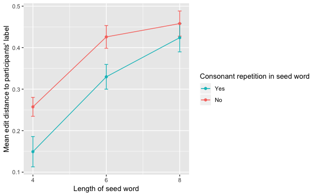

```r
RepAgg = ddply(df_learning_first, c("SeedLength", "SeedRepC"), summarise, mean=mean(dist), sd=sd(dist), n=length(dist))
RepAgg$se = RepAgg$sd/sqrt(RepAgg$n)
RepAgg$SeedRepC = as.factor(RepAgg$SeedRepC)
ggplot(RepAgg, aes(x=SeedLength, y=mean, colour=SeedRepC), group=SeedRepC) +
    geom_errorbar(aes(ymin=mean-se, ymax=mean+se), width=.1) +
    geom_line() +
    scale_x_continuous(breaks = c(4, 6, 8)) +
    geom_point() +
    xlab("Length of seed word") +
    ylab("Mean edit distance to participants' label") +
    scale_colour_discrete(name="Consonant repetition in seed word", breaks = c("1", "0"), labels=c("Yes", "No"))
```

```r
dev.print(pdf, 'Rep effect on learning.pdf')
```

## 4.4 Changes in repetitions: Seeds > First pass > Second pass

Here’s a graphic representation of the changes in repetition we can see going from the seed words to the first pass and second pass in Gen1.

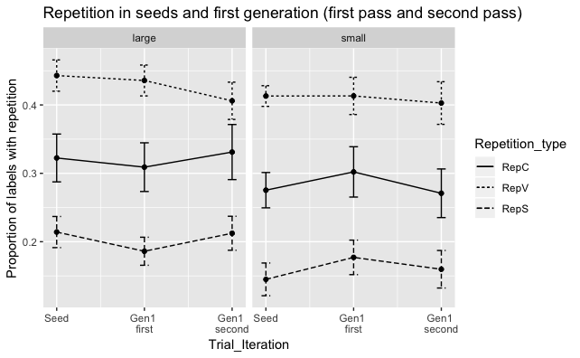

```r
df_director_012 = ddply(subset(df.all, Stage !='interactM' & Generation < 2), c("LexiconType", "Trial_Iteration", "Unique_Participant"), summarise, RepC = mean(ConsonantRepetition), RepV = mean(VowelRepetition), RepS = mean(SyllableRepetition))
df_director_012.long = melt(df_director_012, id.vars = c("LexiconType", "Trial_Iteration", "Unique_Participant"), variable.name = "Repetition_type", value.name = "Mean")
agg_012 = ddply(df_director_012.long, c("LexiconType", "Trial_Iteration", "Repetition_type"), summarise, mean=mean(Mean), sd=sd(Mean), n = length(Mean))
agg_012$se = agg_012$sd/sqrt(24)
ggplot(agg_012, aes(x=Trial_Iteration, y=mean, linetype=Repetition_type)) +
      geom_errorbar(aes(ymin=mean-se, ymax=mean+se), width=.1) +
    geom_line() +
    geom_point() +
  facet_wrap(~ LexiconType) +
  scale_x_continuous(breaks = c(0, 1, 2), labels = c("Seed", "Gen1 \nfirst", "Gen1 \nsecond")) +
  ylab("Proportion of labels with repetition") +
  ggtitle('Repetition in seeds and first generation (first pass and second pass)')
```

## 4.5 Introduction of C rep or V rep

What proportion of seed words that have no C rep get C reps in the first pass? And what propotio of seed words that have no V rep get C reps in the first pass?

```r
Crep0 = ddply(df_learning_first[df_learning_first$SeedRepC == 0, ], c("LexiconType", "SeedLength"), summarise, Crep0to1 = round(mean(ConsonantRepetition), 3))
Crep1 = ddply(df_learning_first[df_learning_first$SeedRepC == 1, ], c("LexiconType", "SeedLength"), summarise, Crep1to1 = round(mean(ConsonantRepetition), 3))
Vrep0 = ddply(df_learning_first[df_learning_first$SeedRepV == 0, ], c("LexiconType", "SeedLength"), summarise, Vrep0to1 = round(mean(VowelRepetition), 3))
Vrep1 = ddply(df_learning_first[df_learning_first$SeedRepV == 1, ], c("LexiconType", "SeedLength"), summarise, Vrep1to1 = round(mean(VowelRepetition), 3))
print(Crep0)
```

```
  LexiconType SeedLength Crep0to1
1       large          4    0.086
2       large          6    0.131
3       large          8    0.118
4       small          4    0.052
5       small          6    0.132
6       small          8    0.295
```

```r
print(Crep1)
```

```
  LexiconType SeedLength Crep1to1
1       large          4    0.786
2       large          6    0.750
3       large          8    0.691
4       small          4    0.800
5       small          6    0.700
6       small          8    0.800
```

```r
print(Vrep0)
```

```
  LexiconType SeedLength Vrep0to1
1       large          4    0.132
2       large          6    0.286
3       large          8    0.417
4       small          4    0.080
5       small          6    0.409
6       small          8    0.542
```

```r
print(Vrep1)
```

```
  LexiconType SeedLength Vrep1to1
1       large          4    0.806
2       large          6    0.726
3       large          8    0.627
4       small          4    0.938
5       small          6    0.641
6       small          8    0.600
```

## 4.6 Exploration of drift from seed words

This plot shows what happens after the first generation/round. There apears to be a shift away from the seed words around Gen 2-3 for the chains, which corresponds to the increase in the repetition in their labels.

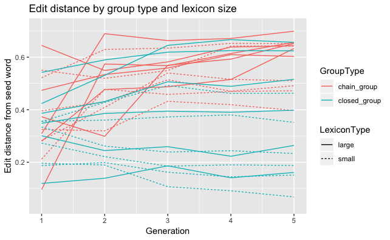

```r
groups = ddply(df_director, c("GroupType", "LexiconType", "GroupNumber"), summarise, n=length(Block))
groups$group_id = factor(LETTERS[1:24])
df_learning_plot = merge(df_learning, groups, all.x = TRUE)
ggplot(df_learning_plot, aes(Generation, dist, group = group_id, colour=GroupType, linetype=LexiconType)) +
  stat_summary(fun.data=mean_se, geom="line") +
  ylab("Edit distance from seed word")+
  ggtitle('Edit distance by group type and lexicon size')
```

```r
dev.print(pdf, 'Edit distance by group type - dog dinner.pdf')
```

# 5 The effect of repetition on communication (as measured by accuracy in Gen1)

## 5.1 Analysis

```r
Instruct = ddply(df.all_director[df.all_director$Generation ==1, ], c("Unique_language", "Block", "Meaning"), summarise, DirLabel = TypedLabel, DirRepC = ConsonantRepetition, DirRepV = VowelRepetition, DirRepS = SyllableRepetition, DirRepCandV = CandV, DirRepCorV = CorV)
df_inst_match= merge(df_matcher, Instruct, all.x = TRUE)
df_inst_match$DirLength = nchar(as.character(df_inst_match$DirLabel))
df_inst_match$sDirLength = scale(df_inst_match$DirLength)
RepCScore = glmer(Score ~ LexiconType*DirRepC*sDirLength + (1|Unique_Participant) + (1|Meaning), data = df_inst_match[df_inst_match$Generation ==1, ], family=binomial, control=glmerControl(optimizer = "bobyqa", optCtrl=list(maxfun=1e5)))
RepVScore = glmer(Score ~ LexiconType*DirRepV*sDirLength + (1|Unique_Participant) + (1|Meaning), data = df_inst_match[df_inst_match$Generation ==1, ], family=binomial, control=glmerControl(optimizer = "bobyqa", optCtrl=list(maxfun=1e5)))
RepSScore = glmer(Score ~ LexiconType*DirRepS*sDirLength + (1|Unique_Participant) + (1|Meaning), data = df_inst_match[df_inst_match$Generation ==1, ], family=binomial, control=glmerControl(optimizer = "bobyqa", optCtrl=list(maxfun=1e5)))
RepCandVScore = glmer(Score ~ LexiconType*DirRepCandV*sDirLength + (1|Unique_Participant) + (1|Meaning), data = df_inst_match[df_inst_match$Generation ==1, ], family=binomial, control=glmerControl(optimizer = "bobyqa", optCtrl=list(maxfun=1e5)))
RepCorVScore = glmer(Score ~ LexiconType*DirRepCorV*sDirLength + (1|Unique_Participant) + (1|Meaning), data = df_inst_match[df_inst_match$Generation ==1, ], family=binomial, control=glmerControl(optimizer = "bobyqa", optCtrl=list(maxfun=1e5)))
summary(RepCScore)
```

```
Generalized linear mixed model fit by maximum likelihood (Laplace Approximation) [
glmerMod]
 Family: binomial  ( logit )
Formula: Score ~ LexiconType * DirRepC * sDirLength + (1 | Unique_Participant) +
    (1 | Meaning)
   Data: df_inst_match[df_inst_match$Generation == 1, ]
Control: glmerControl(optimizer = "bobyqa", optCtrl = list(maxfun = 1e+05))

     AIC      BIC   logLik deviance df.resid
  1772.6   1825.2   -876.3   1752.6     1419

Scaled residuals:
    Min      1Q  Median      3Q     Max
-3.4812 -0.8639  0.4411  0.7246  2.2595

Random effects:
 Groups             Name        Variance Std.Dev.
 Unique_Participant (Intercept) 0.67816  0.8235
 Meaning            (Intercept) 0.06565  0.2562
Number of obs: 1429, groups:  Unique_Participant, 48; Meaning, 18

Fixed effects:
                                Estimate Std. Error z value Pr(>|z|)
(Intercept)                      0.54238    0.15528   3.493 0.000478 ***
LexiconType1                    -0.11952    0.14261  -0.838 0.401966
DirRepC                         -0.20024    0.14619  -1.370 0.170784
sDirLength                      -0.49054    0.07684  -6.384 1.72e-10 ***
LexiconType1:DirRepC            -0.13752    0.14486  -0.949 0.342464
LexiconType1:sDirLength          0.23345    0.07695   3.034 0.002414 **
DirRepC:sDirLength               0.30478    0.14288   2.133 0.032913 *
LexiconType1:DirRepC:sDirLength -0.23167    0.14334  -1.616 0.106048
---
Signif. codes:  0 ‘***’ 0.001 ‘**’ 0.01 ‘*’ 0.05 ‘.’ 0.1 ‘ ’ 1

Correlation of Fixed Effects:
            (Intr) LxcnT1 DirRpC sDrLng LxT1:DRC LT1:DL DRC:DL
LexiconTyp1 -0.072
DirRepC     -0.270  0.050
sDirLength   0.039 -0.008 -0.043
LxcnTy1:DRC  0.052 -0.299 -0.229  0.012
LxcnTyp1:DL  0.017  0.021  0.007 -0.143 -0.045
DrRpC:sDrLn -0.025  0.007 -0.219 -0.543  0.076    0.079
LxT1:DRC:DL -0.011 -0.016  0.078  0.071 -0.209   -0.553 -0.203
```

```r
summary(RepVScore)
```

```
Generalized linear mixed model fit by maximum likelihood (Laplace Approximation) [
glmerMod]
 Family: binomial  ( logit )
Formula: Score ~ LexiconType * DirRepV * sDirLength + (1 | Unique_Participant) +
    (1 | Meaning)
   Data: df_inst_match[df_inst_match$Generation == 1, ]
Control: glmerControl(optimizer = "bobyqa", optCtrl = list(maxfun = 1e+05))

     AIC      BIC   logLik deviance df.resid
  1775.9   1828.5   -877.9   1755.9     1419

Scaled residuals:
    Min      1Q  Median      3Q     Max
-3.4553 -0.8696  0.4385  0.7365  2.2983

Random effects:
 Groups             Name        Variance Std.Dev.
 Unique_Participant (Intercept) 0.68666  0.8287
 Meaning            (Intercept) 0.07054  0.2656
Number of obs: 1429, groups:  Unique_Participant, 48; Meaning, 18

Fixed effects:
                                 Estimate Std. Error z value Pr(>|z|)
(Intercept)                      0.634018   0.161350   3.929 8.51e-05 ***
LexiconType1                    -0.153569   0.148329  -1.035   0.3005
DirRepV                         -0.293281   0.137647  -2.131   0.0331 *
sDirLength                      -0.368013   0.083721  -4.396 1.10e-05 ***
LexiconType1:DirRepV            -0.070269   0.137602  -0.511   0.6096
LexiconType1:sDirLength          0.182299   0.083683   2.178   0.0294 *
DirRepV:sDirLength              -0.002551   0.138294  -0.018   0.9853
LexiconType1:DirRepV:sDirLength -0.031337   0.138641  -0.226   0.8212
---
Signif. codes:  0 ‘***’ 0.001 ‘**’ 0.01 ‘*’ 0.05 ‘.’ 0.1 ‘ ’ 1

Correlation of Fixed Effects:
            (Intr) LxcnT1 DirRpV sDrLng LxT1:DRV LT1:DL DRV:DL
LexiconTyp1 -0.086
DirRepV     -0.332  0.082
sDirLength   0.114 -0.007 -0.120
LxcnTy1:DRV  0.082 -0.363 -0.250  0.001
LxcnTyp1:DL  0.006  0.112 -0.004 -0.131 -0.116
DrRpV:sDrLn -0.069 -0.002 -0.222 -0.606  0.092    0.085
LxT1:DRV:DL -0.002 -0.073  0.094  0.087 -0.227   -0.609 -0.197
```

```r
summary(RepSScore)
```

```
Generalized linear mixed model fit by maximum likelihood (Laplace Approximation) [
glmerMod]
 Family: binomial  ( logit )
Formula: Score ~ LexiconType * DirRepS * sDirLength + (1 | Unique_Participant) +
    (1 | Meaning)
   Data: df_inst_match[df_inst_match$Generation == 1, ]
Control: glmerControl(optimizer = "bobyqa", optCtrl = list(maxfun = 1e+05))

     AIC      BIC   logLik deviance df.resid
  1775.2   1827.9   -877.6   1755.2     1419

Scaled residuals:
    Min      1Q  Median      3Q     Max
-3.5026 -0.8575  0.4428  0.7317  2.3101

Random effects:
 Groups             Name        Variance Std.Dev.
 Unique_Participant (Intercept) 0.68545  0.8279
 Meaning            (Intercept) 0.06854  0.2618
Number of obs: 1429, groups:  Unique_Participant, 48; Meaning, 18

Fixed effects:
                                Estimate Std. Error z value Pr(>|z|)
(Intercept)                      0.56983    0.15323   3.719   0.0002 ***
LexiconType1                    -0.15545    0.13954  -1.114   0.2652
DirRepS                         -0.32873    0.18017  -1.825   0.0681 .
sDirLength                      -0.39779    0.06939  -5.733  9.9e-09 ***
LexiconType1:DirRepS            -0.21887    0.17962  -1.219   0.2230
LexiconType1:sDirLength          0.15717    0.06930   2.268   0.0233 *
DirRepS:sDirLength               0.03288    0.18605   0.177   0.8597
LexiconType1:DirRepS:sDirLength  0.12744    0.18497   0.689   0.4908
---
Signif. codes:  0 ‘***’ 0.001 ‘**’ 0.01 ‘*’ 0.05 ‘.’ 0.1 ‘ ’ 1

Correlation of Fixed Effects:
            (Intr) LxcnT1 DirRpS sDrLng LxT1:DRS LT1:DL DRS:DL
LexiconTyp1 -0.067
DirRepS     -0.182  0.041
sDirLength   0.020  0.012 -0.022
LxcnTy1:DRS  0.041 -0.199 -0.250 -0.014
LxcnTyp1:DL  0.033  0.001 -0.018 -0.106 -0.020
DrRpS:sDrLn -0.023  0.003 -0.371 -0.377  0.086    0.045
LxT1:DRS:DL -0.004 -0.014  0.087  0.043 -0.373   -0.383 -0.287
```

```r
summary(RepCandVScore)
```

```
Generalized linear mixed model fit by maximum likelihood (Laplace Approximation) [
glmerMod]
 Family: binomial  ( logit )
Formula: Score ~ LexiconType * DirRepCandV * sDirLength + (1 | Unique_Participant) +
    (1 | Meaning)
   Data: df_inst_match[df_inst_match$Generation == 1, ]
Control: glmerControl(optimizer = "bobyqa", optCtrl = list(maxfun = 1e+05))

     AIC      BIC   logLik deviance df.resid
  1774.5   1827.1   -877.2   1754.5     1419

Scaled residuals:
    Min      1Q  Median      3Q     Max
-3.4512 -0.8630  0.4458  0.7256  2.2742

Random effects:
 Groups             Name        Variance Std.Dev.
 Unique_Participant (Intercept) 0.66966  0.8183
 Meaning            (Intercept) 0.06916  0.2630
Number of obs: 1429, groups:  Unique_Participant, 48; Meaning, 18

Fixed effects:
                                    Estimate Std. Error z value Pr(>|z|)
(Intercept)                          0.53438    0.15262   3.501 0.000463 ***
LexiconType1                        -0.12383    0.13893  -0.891 0.372752
DirRepCandV                         -0.22715    0.17160  -1.324 0.185594
sDirLength                          -0.44314    0.07132  -6.213 5.19e-10 ***
LexiconType1:DirRepCandV            -0.25106    0.17130  -1.466 0.142759
LexiconType1:sDirLength              0.20467    0.07125   2.873 0.004071 **
DirRepCandV:sDirLength               0.24728    0.17117   1.445 0.148564
LexiconType1:DirRepCandV:sDirLength -0.11192    0.17065  -0.656 0.511925
---
Signif. codes:  0 ‘***’ 0.001 ‘**’ 0.01 ‘*’ 0.05 ‘.’ 0.1 ‘ ’ 1

Correlation of Fixed Effects:
            (Intr) LxcnT1 DrRpCV sDrLng LxT1:DRCV LT1:DL DRCV:D
LexiconTyp1 -0.070
DirRepCandV -0.192  0.041
sDirLength   0.032  0.005 -0.033
LxcnT1:DRCV  0.042 -0.214 -0.231 -0.008
LxcnTyp1:DL  0.024  0.017 -0.012 -0.142 -0.032
DrRpCndV:DL -0.020 -0.001 -0.402 -0.414  0.092     0.065
LT1:DRCV:DL -0.009 -0.016  0.095  0.061 -0.398    -0.422 -0.201
```

```r
summary(RepCorVScore)
```

```
Generalized linear mixed model fit by maximum likelihood (Laplace Approximation) [
glmerMod]
 Family: binomial  ( logit )
Formula: Score ~ LexiconType * DirRepCorV * sDirLength + (1 | Unique_Participant) +
    (1 | Meaning)
   Data: df_inst_match[df_inst_match$Generation == 1, ]
Control: glmerControl(optimizer = "bobyqa", optCtrl = list(maxfun = 1e+05))

     AIC      BIC   logLik deviance df.resid
  1775.0   1827.6   -877.5   1755.0     1419

Scaled residuals:
    Min      1Q  Median      3Q     Max
-3.4701 -0.8700  0.4384  0.7251  2.2100

Random effects:
 Groups             Name        Variance Std.Dev.
 Unique_Participant (Intercept) 0.68114  0.8253
 Meaning            (Intercept) 0.06574  0.2564
Number of obs: 1429, groups:  Unique_Participant, 48; Meaning, 18

Fixed effects:
                                   Estimate Std. Error z value Pr(>|z|)
(Intercept)                         0.65571    0.16555   3.961 7.47e-05 ***
LexiconType1                       -0.15275    0.15380  -0.993   0.3206
DirRepCorV                         -0.31670    0.13416  -2.361   0.0182 *
sDirLength                         -0.41475    0.09319  -4.451 8.56e-06 ***
LexiconType1:DirRepCorV            -0.02240    0.13313  -0.168   0.8664
LexiconType1:sDirLength             0.21616    0.09315   2.321   0.0203 *
DirRepCorV:sDirLength               0.09453    0.13432   0.704   0.4816
LexiconType1:DirRepCorV:sDirLength -0.12442    0.13403  -0.928   0.3532
---
Signif. codes:  0 ‘***’ 0.001 ‘**’ 0.01 ‘*’ 0.05 ‘.’ 0.1 ‘ ’ 1

Correlation of Fixed Effects:
            (Intr) LxcnT1 DrRpCV sDrLng LxT1:DRCV LT1:DL DRCV:D
LexiconTyp1 -0.095
DirRepCorV  -0.413  0.093
sDirLength   0.145 -0.030 -0.159
LxcnT1:DRCV  0.095 -0.448 -0.235  0.027
LxcnTyp1:DL -0.009  0.142  0.021 -0.143 -0.160
DrRpCrV:sDL -0.101  0.017 -0.086 -0.703  0.058     0.108
LT1:DRCV:DL  0.006 -0.103  0.062  0.107 -0.082    -0.707 -0.199
```

## 5.2 Plot

Here’s a plot showing the effects of the length of the director’s word and lexicon size. Because there were very few director words with odd numbers of segments or with segments below 4, length was collapsed into 3 categories. It can be seen from this that those communicating the small lexicon are more accurate than those with the large lexicon, but this effect disappears when the words get long.

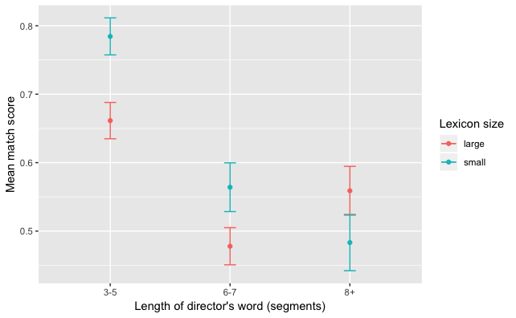

```r
df_inst_match$DirLengthCat[df_inst_match$DirLength >= 8] <- "8+"
df_inst_match$DirLengthCat[df_inst_match$DirLength >= 6 & df_inst_match$DirLength < 8] <- "6-7"
df_inst_match$DirLengthCat[df_inst_match$DirLength < 6] <- "3-5"
Gen1ComAgg = ddply(df_inst_match[df_inst_match$Generation == 1, ], c("LexiconType", "DirLengthCat"), summarise, mean=mean(Score), sd=sd(Score), n=length(Score))
Gen1ComAgg$se = Gen1ComAgg$sd/sqrt(Gen1ComAgg$n)
Gen1ComAgg=Gen1ComAgg[complete.cases(Gen1ComAgg), ]
ggplot(Gen1ComAgg, aes(x=DirLengthCat, y=mean, colour=LexiconType), group=LexiconType) +
    geom_errorbar(aes(ymin=mean-se, ymax=mean+se), width=.1) +
    geom_line() +
    geom_point() +
    xlab("Length of director's word (segments)") +
    ylab("Mean match score") +
    scale_colour_discrete(name="Lexicon size")
```

```r
dev.print(pdf, '`lexiconSize_wordLength_accuracy.pdf')
```

# 6 Analysis of consonant repetition (“CVC”)

## 6.1 CVC: Descriptive plot

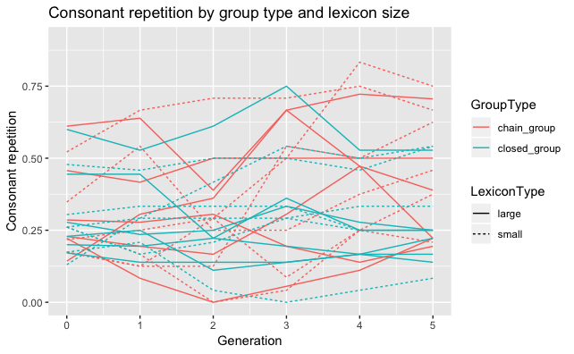

```r
groups = ddply(df_director, c("GroupType", "LexiconType", "GroupNumber"), summarise, n=length(Block))
groups$group_id = factor(LETTERS[1:24])
df_director_plot = merge(df_director, groups, all.x = TRUE)
ggplot(df_director_plot, aes(Generation, ConsonantRepetition, group = group_id, colour=GroupType, linetype=LexiconType)) +
  stat_summary(fun.data=mean_se, geom="line") +
  ylab("Consonant repetition")+
  ggtitle('Consonant repetition by group type and lexicon size')
```

```r
dev.print(pdf, 'Consonant repetition by group type - dog dinner.pdf')
```

## 6.2 CVC: Full models

```r
# CVC_third_order <- glmer(ConsonantRepetition ~ #maximal random effect structure, up to cubic term
#                 (ot1+ot2+ot3) * GroupType * LexiconType + (1+ot1+ot2+ot3|Unique_Participant) +
#                 (1+ot1+ot2+ot3 |Meaning) + (1+ot1+ot2+ot3|Pair), data=df_director, family=binomial,
#                 control=glmerControl(optimizer = "bobyqa", optCtrl=list(maxfun=1e5)))
#CVC_second_order <- glmer(ConsonantRepetition ~ #maximal random effect structure, up to quadratic term
#                 (ot1+ot2) * GroupType * LexiconType + (1+ot1+ot2|Unique_Participant) +
#                 (1+ot1+ot2 |Meaning) + (1+ot1+ot2|Pair), data=df_director, family=binomial,
#                 control=glmerControl(optimizer = "bobyqa", optCtrl=list(maxfun=1e5)))
#CVC_first_order <- glmer(ConsonantRepetition ~ #maximal random effect structure, up to linear term
#                 ot1 * GroupType * LexiconType + (1+ot1|Unique_Participant) + (1+ot1 |Meaning) +
#                 (1+ot1+ot2|Pair), data=df_director, family=binomial,
#                 control=glmerControl(optimizer = "bobyqa", optCtrl=list(maxfun=1e5)))
```

## 6.3 CVC: Reduced models

The full models above all result in singular fit. The models converge without singular fit when all the random slopes are removed and ‘Pair’ is also removed as a random effect.Below are models with these terms dropped.

```r
CVC_third_order <- glmer(ConsonantRepetition ~ #maximal random effect structure, up to cubic term
                  (ot1+ot2+ot3) * GroupType * LexiconType + (1|Unique_Participant) + (1|Meaning),
                  data=df_director, family=binomial,
                  control=glmerControl(optimizer = "bobyqa", optCtrl=list(maxfun=1e5)))
CVC_second_order <- glmer(ConsonantRepetition ~ #maximal random effect structure, up to quadratic term
                    (ot1+ot2) * GroupType * LexiconType + (1|Unique_Participant) + (1|Meaning),
                   data=df_director, family=binomial,
                   control=glmerControl(optimizer = "bobyqa", optCtrl=list(maxfun=1e5)))
CVC_first_order <- glmer(ConsonantRepetition ~ #maximal random effect structure, up to linear term
                    ot1 * GroupType * LexiconType + (1|Unique_Participant) + (1|Meaning),
                    data=df_director, family=binomial,
                    control=glmerControl(optimizer = "bobyqa", optCtrl=list(maxfun=1e5)))
summary(CVC_third_order)
```

```
Generalized linear mixed model fit by maximum likelihood (Laplace Approximation) [
glmerMod]
 Family: binomial  ( logit )
Formula: ConsonantRepetition ~ (ot1 + ot2 + ot3) * GroupType * LexiconType +
    (1 | Unique_Participant) + (1 | Meaning)
   Data: df_director
Control: glmerControl(optimizer = "bobyqa", optCtrl = list(maxfun = 1e+05))

     AIC      BIC   logLik deviance df.resid
  5006.3   5120.9  -2485.2   4970.3     4277

Scaled residuals:
    Min      1Q  Median      3Q     Max
-2.1401 -0.6326 -0.4500  0.8394  4.4073

Random effects:
 Groups             Name        Variance Std.Dev.
 Unique_Participant (Intercept) 0.7375   0.8588
 Meaning            (Intercept) 0.2399   0.4898
Number of obs: 4295, groups:  Unique_Participant, 156; Meaning, 18

Fixed effects:
                              Estimate Std. Error z value Pr(>|z|)
(Intercept)                 -0.8518629  0.1518173  -5.611 2.01e-08 ***
ot1                          0.3221164  0.1810502   1.779  0.07521 .
ot2                          0.1296986  0.1732547   0.749  0.45410
ot3                         -0.1590013  0.1490403  -1.067  0.28605
GroupType1                   0.1527234  0.0861046   1.774  0.07611 .
LexiconType1                -0.0459846  0.0981221  -0.469  0.63932
ot1:GroupType1               0.3636177  0.1236465   2.941  0.00327 **
ot2:GroupType1               0.1132861  0.1241318   0.913  0.36144
ot3:GroupType1              -0.0983222  0.1243676  -0.791  0.42919
ot1:LexiconType1            -0.2932724  0.1810698  -1.620  0.10530
ot2:LexiconType1            -0.0681952  0.1731292  -0.394  0.69366
ot3:LexiconType1            -0.0643197  0.1490052  -0.432  0.66599
GroupType1:LexiconType1     -0.0002823  0.0860539  -0.003  0.99738
ot1:GroupType1:LexiconType1 -0.0549460  0.1236074  -0.445  0.65667
ot2:GroupType1:LexiconType1 -0.0888149  0.1240177  -0.716  0.47390
ot3:GroupType1:LexiconType1  0.0088416  0.1243509   0.071  0.94332
---
Signif. codes:  0 ‘***’ 0.001 ‘**’ 0.01 ‘*’ 0.05 ‘.’ 0.1 ‘ ’ 1
```

```
Correlation matrix not shown by default, as p = 16 > 12.
Use print(x, correlation=TRUE)  or
    vcov(x)        if you need it
```

```r
summary(CVC_second_order)
```

```
Generalized linear mixed model fit by maximum likelihood (Laplace Approximation) [
glmerMod]
 Family: binomial  ( logit )
Formula: ConsonantRepetition ~ (ot1 + ot2) * GroupType * LexiconType +
    (1 | Unique_Participant) + (1 | Meaning)
   Data: df_director
Control: glmerControl(optimizer = "bobyqa", optCtrl = list(maxfun = 1e+05))

     AIC      BIC   logLik deviance df.resid
  4999.9   5089.1  -2486.0   4971.9     4281

Scaled residuals:
    Min      1Q  Median      3Q     Max
-2.1234 -0.6372 -0.4509  0.8395  4.4616

Random effects:
 Groups             Name        Variance Std.Dev.
 Unique_Participant (Intercept) 0.7457   0.8635
 Meaning            (Intercept) 0.2399   0.4898
Number of obs: 4295, groups:  Unique_Participant, 156; Meaning, 18

Fixed effects:
                             Estimate Std. Error z value Pr(>|z|)
(Intercept)                 -0.865563   0.151357  -5.719 1.07e-08 ***
ot1                          0.378456   0.159281   2.376  0.01750 *
ot2                          0.076921   0.154086   0.499  0.61763
GroupType1                   0.155856   0.081925   1.902  0.05712 .
LexiconType1                -0.046802   0.097341  -0.481  0.63066
ot1:GroupType1               0.344912   0.122334   2.819  0.00481 **
ot2:GroupType1               0.127871   0.123305   1.037  0.29972
ot1:LexiconType1            -0.249745   0.159233  -1.568  0.11678
ot2:LexiconType1            -0.107087   0.154037  -0.695  0.48693
GroupType1:LexiconType1     -0.008836   0.081899  -0.108  0.91408
ot1:GroupType1:LexiconType1 -0.065244   0.122326  -0.533  0.59378
ot2:GroupType1:LexiconType1 -0.079199   0.123141  -0.643  0.52012
---
Signif. codes:  0 ‘***’ 0.001 ‘**’ 0.01 ‘*’ 0.05 ‘.’ 0.1 ‘ ’ 1

Correlation of Fixed Effects:
            (Intr) ot1    ot2    GrpTy1 LxcnT1 ot1:GT1 ot2:GT1 o1:LT1 o2:LT1 GT1:LT
```

[output cut: 8 more lines]

```
GrpTyp1:LT1  0.005  0.022 -0.018 -0.057 -0.496  0.007   0.001  -0.010  0.001
ot1:GT1:LT1  0.001  0.005 -0.008  0.007 -0.274 -0.097   0.016   0.242  0.133  0.405
ot2:GT1:LT1  0.002 -0.006 -0.002  0.002  0.235  0.017  -0.097   0.130  0.279 -0.378
            o1:GT1:
ot1
ot2
GroupType1
LexiconTyp1
ot1:GrpTyp1
ot2:GrpTyp1
ot1:LxcnTy1
ot2:LxcnTy1
GrpTyp1:LT1
ot1:GT1:LT1
ot2:GT1:LT1  0.026
```

```r
summary(CVC_first_order)
```

```
Generalized linear mixed model fit by maximum likelihood (Laplace Approximation) [
glmerMod]
 Family: binomial  ( logit )
Formula:
ConsonantRepetition ~ ot1 * GroupType * LexiconType + (1 | Unique_Participant) +
    (1 | Meaning)
   Data: df_director
Control: glmerControl(optimizer = "bobyqa", optCtrl = list(maxfun = 1e+05))

     AIC      BIC   logLik deviance df.resid
  4993.7   5057.3  -2486.8   4973.7     4285

Scaled residuals:
    Min      1Q  Median      3Q     Max
-2.1277 -0.6373 -0.4512  0.8397  4.5419

Random effects:
 Groups             Name        Variance Std.Dev.
 Unique_Participant (Intercept) 0.7479   0.8648
 Meaning            (Intercept) 0.2399   0.4898
Number of obs: 4295, groups:  Unique_Participant, 156; Meaning, 18

Fixed effects:
                            Estimate Std. Error z value Pr(>|z|)
(Intercept)                 -0.88887    0.14973  -5.936 2.91e-09 ***
ot1                          0.37328    0.14295   2.611  0.00902 **
GroupType1                   0.18425    0.07529   2.447  0.01439 *
LexiconType1                -0.03217    0.09454  -0.340  0.73363
ot1:GroupType1               0.33956    0.12136   2.798  0.00514 **
ot1:LexiconType1            -0.27564    0.14295  -1.928  0.05382 .
GroupType1:LexiconType1     -0.02068    0.07529  -0.275  0.78360
ot1:GroupType1:LexiconType1 -0.05691    0.12135  -0.469  0.63911
---
Signif. codes:  0 ‘***’ 0.001 ‘**’ 0.01 ‘*’ 0.05 ‘.’ 0.1 ‘ ’ 1

Correlation of Fixed Effects:
            (Intr) ot1    GrpTy1 LxcnT1 ot1:GT1 o1:LT1 GT1:LT
ot1         -0.102
GroupType1  -0.293  0.105
LexiconTyp1 -0.042  0.000  0.019
ot1:GrpTyp1 -0.189  0.333  0.439 -0.004
ot1:LxcnTy1  0.000 -0.097  0.027 -0.160 -0.004
GrpTyp1:LT1  0.014  0.027 -0.083 -0.461  0.018   0.105
ot1:GT1:LT1 -0.001 -0.004  0.018 -0.298 -0.099   0.333  0.439
```

## 6.4 CVC: Model comparison

```r
CVC_model.names <- c("CVC first order","CVC second order","CVC third order")
CVC_summ.table <- do.call(rbind, lapply(list(CVC_first_order,CVC_second_order,CVC_third_order), broom::glance))
CVC_table.cols <- c("df.residual", "deviance", "AIC")
CVC_reported.table <- CVC_summ.table[CVC_table.cols]
names(CVC_reported.table) <- c("Resid.Df", "Resid.Dev", "AIC")
CVC_reported.table[['dAIC']] <-  with(CVC_reported.table, AIC - min(AIC))
CVC_reported.table[['AIC_weight']] <- with(CVC_reported.table, exp(- 0.5 * dAIC) / sum(exp(- 0.5 * dAIC)))
CVC_reported.table$AIC <- NULL
CVC_reported.table$AIC_weight <- round(CVC_reported.table$AIC_weight, 2)
CVC_reported.table$dAIC <- round(CVC_reported.table$dAIC, 1)
CVC_reported.table$Resid.Dev <- round(CVC_reported.table$Resid.Dev, 2)
row.names(CVC_reported.table) <- CVC_model.names
```

```
Setting row names on a tibble is deprecated.
```

```r
View(CVC_reported.table)
sjPlot::tab_df(CVC_reported.table,
       file="model comparison CVC.doc")
```

## 6.5 CVC: Plots showing model fit of 1st order model by group type

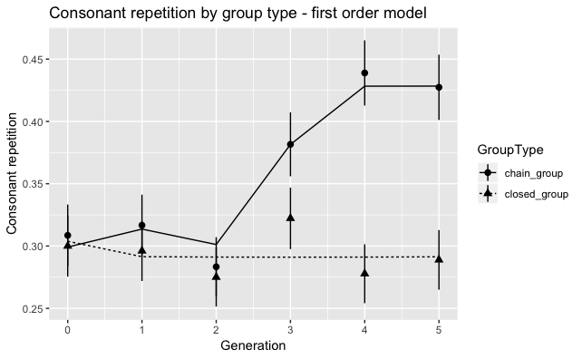

```r
ggplot(df_director, aes(Generation, ConsonantRepetition, shape=GroupType)) +
  stat_summary(fun.data=mean_se, geom="pointrange") +
  stat_summary(aes(y=fitted(CVC_first_order), linetype=GroupType),
               fun.y=mean, geom="line") +
  ylab("Consonant repetition")+
  ggtitle('Consonant repetition by group type - first order model')
```

```r
dev.print(pdf, 'Consonant repetition by group type - first order model.pdf')
```

## 6.6 CVC: Plots showing model fit of 1st model by lexicon type

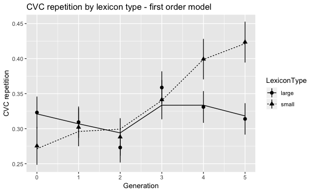

```r
ggplot(df_director, aes(Generation, ConsonantRepetition, shape=LexiconType)) +
  stat_summary(fun.data=mean_se, geom="pointrange") +
  stat_summary(aes(y=fitted(CVC_first_order), linetype=LexiconType),
               fun.y=mean, geom="line") +
  ylab("CVC repetition") +
  ggtitle('CVC repetition by lexicon type - first order model')
```

```r
dev.print(pdf,'CVC repetition by lexicon type - first order model.pdf')
```

# 7 Analysis of adjacent vowel repetition (VCV)

## 7.1 Descriptive plot

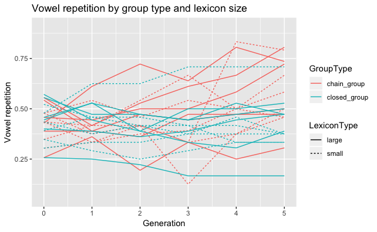

```r
ggplot(df_director_plot, aes(Generation, VowelRepetition, group = group_id, colour=GroupType, linetype=LexiconType)) +
  stat_summary(fun.data=mean_se, geom="line") +
  ylab("Vowel repetition")+
  ggtitle('Vowel repetition by group type and lexicon size')
```

```r
dev.print(pdf, 'Vowel repetition by group type - dog dinner.pdf')
```

## 7.2 VCV: Reduced models

```r
VCV_third_order <- glmer(VowelRepetition ~ #maximal random effect structure, up to cubic term
                  (ot1+ot2+ot3) * GroupType * LexiconType + (1|Unique_Participant) + (1|Meaning),
                  data=df_director, family=binomial,
                  control=glmerControl(optimizer = "bobyqa", optCtrl=list(maxfun=1e5)))
VCV_second_order <- glmer(VowelRepetition ~ #maximal random effect structure, up to quadratic term
                    (ot1+ot2) * GroupType * LexiconType + (1|Unique_Participant) + (1|Meaning),
                   data=df_director, family=binomial,
                   control=glmerControl(optimizer = "bobyqa", optCtrl=list(maxfun=1e5)))
VCV_first_order <- glmer(VowelRepetition ~ #maximal random effect structure, up to linear term
                    ot1 * GroupType * LexiconType + (1|Unique_Participant) + (1|Meaning),
                    data=df_director, family=binomial,
                    control=glmerControl(optimizer = "bobyqa", optCtrl=list(maxfun=1e5)))
summary(VCV_third_order)
```

```
Generalized linear mixed model fit by maximum likelihood (Laplace Approximation) [
glmerMod]
 Family: binomial  ( logit )
Formula: VowelRepetition ~ (ot1 + ot2 + ot3) * GroupType * LexiconType +
    (1 | Unique_Participant) + (1 | Meaning)
   Data: df_director
Control: glmerControl(optimizer = "bobyqa", optCtrl = list(maxfun = 1e+05))

     AIC      BIC   logLik deviance df.resid
  5781.9   5896.5  -2873.0   5745.9     4277

Scaled residuals:
    Min      1Q  Median      3Q     Max
-1.6241 -0.8685 -0.6330  1.0094  2.6121

Random effects:
 Groups             Name        Variance Std.Dev.
 Unique_Participant (Intercept) 0.1542   0.3927
 Meaning            (Intercept) 0.0959   0.3097
Number of obs: 4295, groups:  Unique_Participant, 156; Meaning, 18

Fixed effects:
                             Estimate Std. Error z value Pr(>|z|)
(Intercept)                 -0.263461   0.090859  -2.900 0.003735 **
ot1                          0.249106   0.110332   2.258 0.023959 *
ot2                          0.168754   0.107112   1.575 0.115144
ot3                         -0.004114   0.097661  -0.042 0.966402
GroupType1                   0.128955   0.048662   2.650 0.008048 **
LexiconType1                 0.058398   0.053897   1.084 0.278578
ot1:GroupType1               0.307848   0.088959   3.461 0.000539 ***
ot2:GroupType1               0.069689   0.088913   0.784 0.433165
ot3:GroupType1               0.008874   0.088765   0.100 0.920369
ot1:LexiconType1            -0.045589   0.110330  -0.413 0.679458
ot2:LexiconType1             0.028365   0.107047   0.265 0.791029
ot3:LexiconType1            -0.009667   0.097650  -0.099 0.921139
GroupType1:LexiconType1      0.057120   0.048652   1.174 0.240373
ot1:GroupType1:LexiconType1  0.039765   0.088918   0.447 0.654722
ot2:GroupType1:LexiconType1 -0.108133   0.088915  -1.216 0.223932
ot3:GroupType1:LexiconType1 -0.047308   0.088765  -0.533 0.594059
---
Signif. codes:  0 ‘***’ 0.001 ‘**’ 0.01 ‘*’ 0.05 ‘.’ 0.1 ‘ ’ 1
```

```
Correlation matrix not shown by default, as p = 16 > 12.
Use print(x, correlation=TRUE)  or
    vcov(x)        if you need it
```

```r
summary(VCV_second_order)
```

```
Generalized linear mixed model fit by maximum likelihood (Laplace Approximation) [
glmerMod]
 Family: binomial  ( logit )
Formula: VowelRepetition ~ (ot1 + ot2) * GroupType * LexiconType + (1 |
    Unique_Participant) + (1 | Meaning)
   Data: df_director
Control: glmerControl(optimizer = "bobyqa", optCtrl = list(maxfun = 1e+05))

     AIC      BIC   logLik deviance df.resid
  5774.2   5863.3  -2873.1   5746.2     4281

Scaled residuals:
    Min      1Q  Median      3Q     Max
-1.6346 -0.8682 -0.6354  1.0102  2.6226

Random effects:
 Groups             Name        Variance Std.Dev.
 Unique_Participant (Intercept) 0.15445  0.3930
 Meaning            (Intercept) 0.09586  0.3096
Number of obs: 4295, groups:  Unique_Participant, 156; Meaning, 18

Fixed effects:
                            Estimate Std. Error z value Pr(>|z|)
(Intercept)                 -0.26346    0.09074  -2.904 0.003690 **
ot1                          0.25083    0.10624   2.361 0.018229 *
ot2                          0.16735    0.10359   1.615 0.106219
GroupType1                   0.12864    0.04799   2.680 0.007356 **
LexiconType1                 0.05597    0.05372   1.042 0.297396
ot1:GroupType1               0.30738    0.08871   3.465 0.000531 ***
ot2:GroupType1               0.07021    0.08869   0.792 0.428573
ot1:LexiconType1            -0.04841    0.10625  -0.456 0.648682
ot2:LexiconType1             0.03112    0.10356   0.300 0.763827
GroupType1:LexiconType1      0.06048    0.04801   1.260 0.207750
ot1:GroupType1:LexiconType1  0.03973    0.08868   0.448 0.654149
ot2:GroupType1:LexiconType1 -0.10798    0.08869  -1.217 0.223420
---
Signif. codes:  0 ‘***’ 0.001 ‘**’ 0.01 ‘*’ 0.05 ‘.’ 0.1 ‘ ’ 1

Correlation of Fixed Effects:
            (Intr) ot1    ot2    GrpTy1 LxcnT1 ot1:GT1 ot2:GT1 o1:LT1 o2:LT1 GT1:LT
```

[output cut: 8 more lines]

```
GrpTyp1:LT1 -0.001  0.008 -0.003 -0.095 -0.337  0.005  -0.001  -0.077  0.074
ot1:GT1:LT1  0.000  0.004 -0.001  0.004 -0.138 -0.160   0.007   0.077  0.088  0.213
ot2:GT1:LT1  0.003 -0.002  0.002 -0.002  0.128  0.006  -0.160   0.085  0.094 -0.194
            o1:GT1:
ot1
ot2
GroupType1
LexiconTyp1
ot1:GrpTyp1
ot2:GrpTyp1
ot1:LxcnTy1
ot2:LxcnTy1
GrpTyp1:LT1
ot1:GT1:LT1
ot2:GT1:LT1  0.004
```

```r
summary(VCV_first_order)
```

```
Generalized linear mixed model fit by maximum likelihood (Laplace Approximation) [
glmerMod]
 Family: binomial  ( logit )
Formula:
VowelRepetition ~ ot1 * GroupType * LexiconType + (1 | Unique_Participant) +
    (1 | Meaning)
   Data: df_director
Control: glmerControl(optimizer = "bobyqa", optCtrl = list(maxfun = 1e+05))

     AIC      BIC   logLik deviance df.resid
  5770.9   5834.5  -2875.4   5750.9     4285

Scaled residuals:
    Min      1Q  Median      3Q     Max
-1.6238 -0.8694 -0.6307  1.0080  2.5381

Random effects:
 Groups             Name        Variance Std.Dev.
 Unique_Participant (Intercept) 0.15841  0.3980
 Meaning            (Intercept) 0.09585  0.3096
Number of obs: 4295, groups:  Unique_Participant, 156; Meaning, 18

Fixed effects:
                            Estimate Std. Error z value Pr(>|z|)
(Intercept)                 -0.27134    0.09068  -2.992 0.002767 **
ot1                          0.29582    0.10168   2.909 0.003623 **
GroupType1                   0.12711    0.04714   2.697 0.007004 **
LexiconType1                 0.06254    0.05357   1.167 0.243085
ot1:GroupType1               0.29556    0.08862   3.335 0.000852 ***
ot1:LexiconType1            -0.02165    0.10161  -0.213 0.831311
GroupType1:LexiconType1      0.04746    0.04711   1.007 0.313763
ot1:GroupType1:LexiconType1  0.03500    0.08861   0.395 0.692828
---
Signif. codes:  0 ‘***’ 0.001 ‘**’ 0.01 ‘*’ 0.05 ‘.’ 0.1 ‘ ’ 1

Correlation of Fixed Effects:
            (Intr) ot1    GrpTy1 LxcnT1 ot1:GT1 o1:LT1 GT1:LT
ot1         -0.037
GroupType1  -0.197 -0.034
LexiconTyp1 -0.082  0.004  0.008
ot1:GrpTyp1 -0.088  0.110  0.213  0.001
ot1:LxcnTy1  0.000 -0.138  0.015 -0.059  0.004
GrpTyp1:LT1  0.003  0.014 -0.108 -0.330  0.006  -0.036
ot1:GT1:LT1  0.000  0.004  0.006 -0.147 -0.161   0.110  0.213
```

# 8 VCV: Model comparison

```r
VCV_model.names <- c("VCV first order","VCV second order","VCV third order")
VCV_summ.table <- do.call(rbind, lapply(list(VCV_first_order,VCV_second_order,VCV_third_order), broom::glance))
VCV_table.cols <- c("df.residual", "deviance", "AIC")
VCV_reported.table <- VCV_summ.table[VCV_table.cols]
names(VCV_reported.table) <- c("Resid.Df", "Resid.Dev", "AIC")
VCV_reported.table[['dAIC']] <-  with(VCV_reported.table, AIC - min(AIC))
VCV_reported.table[['AIC_weight']] <- with(VCV_reported.table, exp(- 0.5 * dAIC) / sum(exp(- 0.5 * dAIC)))
VCV_reported.table$AIC <- NULL
VCV_reported.table$AIC_weight <- round(VCV_reported.table$AIC_weight, 2)
VCV_reported.table$dAIC <- round(VCV_reported.table$dAIC, 1)
VCV_reported.table$Resid.Dev <- round(VCV_reported.table$Resid.Dev, 2)
row.names(VCV_reported.table) <- VCV_model.names
```

```
Setting row names on a tibble is deprecated.
```

```r
View(VCV_reported.table)
sjPlot::tab_df(VCV_reported.table,
       file="model comparison VCV.doc")
```

## 8.1 VCV: Plots showing model fit of 1st order model by group type

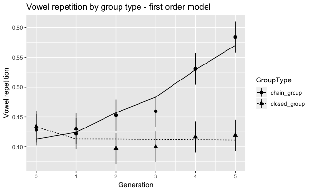

```r
ggplot(df_director, aes(Generation, VowelRepetition, shape=GroupType)) +
  stat_summary(fun.data=mean_se, geom="pointrange") +
  stat_summary(aes(y=fitted(VCV_first_order), linetype=GroupType),
               fun.y=mean, geom="line") +
  ylab("Vowel repetition")+
  ggtitle('Vowel repetition by group type - first order model')
```

```r
dev.print(pdf, 'Vowel repetition by group type - first order model.pdf')
```

## 8.2 VCV: Plots showing model fit of 1st model by lexicon type

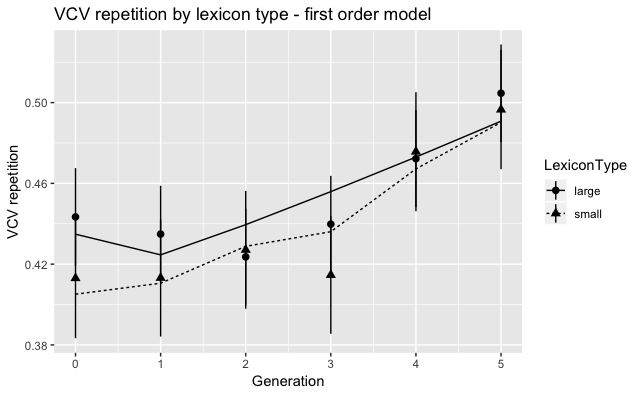

```r
ggplot(df_director, aes(Generation, VowelRepetition, shape=LexiconType)) +
  stat_summary(fun.data=mean_se, geom="pointrange") +
  stat_summary(aes(y=fitted(VCV_first_order), linetype=LexiconType),
               fun.y=mean, geom="line") +
  ylab("VCV repetition") +
  ggtitle('VCV repetition by lexicon type - first order model')
```

```r
dev.print(pdf,'VCV repetition by lexicon type - first order model.pdf')
```

# 9 Analysis of ‘CandV rep’ (i.e., C rep & V rep)

## 9.1 Descriptive plot

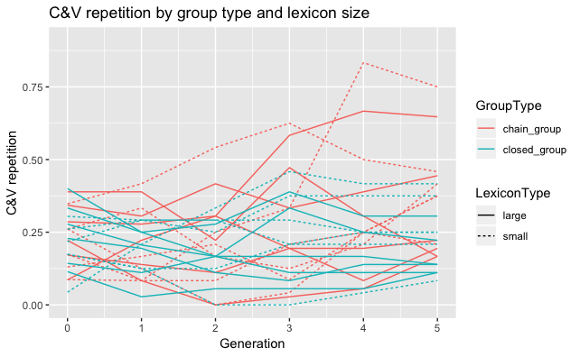

```r
ggplot(df_director_plot, aes(Generation, CandV, group = group_id, colour=GroupType, linetype=LexiconType)) +
  stat_summary(fun.data=mean_se, geom="line") +
  ylab("C&V repetition")+
  ggtitle('C&V repetition by group type and lexicon size')
```

```r
dev.print(pdf, 'C&V repetition by group type - dog dinner.pdf')
```

## 9.2 CandV: Reduced models

```r
CandV_third_order <- glmer(CandV ~ #maximal random effect structure, up to cubic term
                  (ot1+ot2+ot3) * GroupType * LexiconType + (1|Unique_Participant) + (1|Meaning),
                  data=df_director, family=binomial,
                  control=glmerControl(optimizer = "bobyqa", optCtrl=list(maxfun=1e5)))
CandV_second_order <- glmer(CandV ~ #maximal random effect structure, up to quadratic term
                    (ot1+ot2) * GroupType * LexiconType + (1|Unique_Participant) + (1|Meaning),
                   data=df_director, family=binomial,
                   control=glmerControl(optimizer = "bobyqa", optCtrl=list(maxfun=1e5)))
CandV_first_order <- glmer(CandV ~ #maximal random effect structure, up to linear term
                    ot1 * GroupType * LexiconType + (1|Unique_Participant) + (1|Meaning),
                    data=df_director, family=binomial,
                    control=glmerControl(optimizer = "bobyqa", optCtrl=list(maxfun=1e5)))
summary(CandV_third_order)
```

```
Generalized linear mixed model fit by maximum likelihood (Laplace Approximation) [
glmerMod]
 Family: binomial  ( logit )
Formula:
CandV ~ (ot1 + ot2 + ot3) * GroupType * LexiconType + (1 | Unique_Participant) +
    (1 | Meaning)
   Data: df_director
Control: glmerControl(optimizer = "bobyqa", optCtrl = list(maxfun = 1e+05))

     AIC      BIC   logLik deviance df.resid
  4500.3   4614.9  -2232.1   4464.3     4277

Scaled residuals:
    Min      1Q  Median      3Q     Max
-1.5084 -0.5701 -0.4295 -0.2445  4.2573

Random effects:
 Groups             Name        Variance Std.Dev.
 Unique_Participant (Intercept) 0.5187   0.7202
 Meaning            (Intercept) 0.1142   0.3380
Number of obs: 4295, groups:  Unique_Participant, 156; Meaning, 18

Fixed effects:
                             Estimate Std. Error z value Pr(>|z|)
(Intercept)                 -1.319704   0.118374 -11.149  < 2e-16 ***
ot1                          0.342326   0.166291   2.059  0.03953 *
ot2                          0.227089   0.160179   1.418  0.15627
ot3                         -0.151879   0.139430  -1.089  0.27603
GroupType1                   0.168713   0.076946   2.193  0.02834 *
LexiconType1                -0.069021   0.086370  -0.799  0.42421
ot1:GroupType1               0.330372   0.118624   2.785  0.00535 **
ot2:GroupType1               0.102226   0.119459   0.856  0.39214
ot3:GroupType1               0.002972   0.119593   0.025  0.98017
ot1:LexiconType1            -0.322097   0.166288  -1.937  0.05275 .
ot2:LexiconType1            -0.041173   0.160010  -0.257  0.79693
ot3:LexiconType1            -0.028281   0.139461  -0.203  0.83930
GroupType1:LexiconType1      0.063513   0.076911   0.826  0.40892
ot1:GroupType1:LexiconType1 -0.046276   0.118658  -0.390  0.69654
ot2:GroupType1:LexiconType1 -0.162076   0.119286  -1.359  0.17424
ot3:GroupType1:LexiconType1  0.059541   0.119594   0.498  0.61858
---
Signif. codes:  0 ‘***’ 0.001 ‘**’ 0.01 ‘*’ 0.05 ‘.’ 0.1 ‘ ’ 1
```

```
Correlation matrix not shown by default, as p = 16 > 12.
Use print(x, correlation=TRUE)  or
    vcov(x)        if you need it
```

```r
summary(CandV_second_order)
```

```
Generalized linear mixed model fit by maximum likelihood (Laplace Approximation) [
glmerMod]
 Family: binomial  ( logit )
Formula: CandV ~ (ot1 + ot2) * GroupType * LexiconType + (1 | Unique_Participant) +
    (1 | Meaning)
   Data: df_director
Control: glmerControl(optimizer = "bobyqa", optCtrl = list(maxfun = 1e+05))

     AIC      BIC   logLik deviance df.resid
  4493.9   4583.1  -2233.0   4465.9     4281

Scaled residuals:
    Min      1Q  Median      3Q     Max
-1.5010 -0.5692 -0.4291 -0.2467  4.2334

Random effects:
 Groups             Name        Variance Std.Dev.
 Unique_Participant (Intercept) 0.5247   0.7243
 Meaning            (Intercept) 0.1142   0.3380
Number of obs: 4295, groups:  Unique_Participant, 156; Meaning, 18

Fixed effects:
                            Estimate Std. Error z value Pr(>|z|)
(Intercept)                 -1.32120    0.11807 -11.190  < 2e-16 ***
ot1                          0.41626    0.15268   2.726  0.00640 **
ot2                          0.15643    0.14699   1.064  0.28723
GroupType1                   0.15384    0.07451   2.065  0.03895 *
LexiconType1                -0.06389    0.08597  -0.743  0.45737
ot1:GroupType1               0.31304    0.11775   2.658  0.00785 **
ot2:GroupType1               0.11539    0.11896   0.970  0.33205
ot1:LexiconType1            -0.28826    0.15250  -1.890  0.05873 .
ot2:LexiconType1            -0.06938    0.14714  -0.472  0.63725
GroupType1:LexiconType1      0.04971    0.07443   0.668  0.50424
ot1:GroupType1:LexiconType1 -0.05029    0.11781  -0.427  0.66947
ot2:GroupType1:LexiconType1 -0.15645    0.11867  -1.318  0.18737
---
Signif. codes:  0 ‘***’ 0.001 ‘**’ 0.01 ‘*’ 0.05 ‘.’ 0.1 ‘ ’ 1

Correlation of Fixed Effects:
            (Intr) ot1    ot2    GrpTy1 LxcnT1 ot1:GT1 ot2:GT1 o1:LT1 o2:LT1 GT1:LT
```

[output cut: 8 more lines]

```
GrpTyp1:LT1  0.002  0.008  0.001 -0.055 -0.461  0.030  -0.012  -0.067  0.049
ot1:GT1:LT1  0.003 -0.010  0.000  0.032 -0.240 -0.107   0.033   0.141  0.116  0.329
ot2:GT1:LT1  0.010  0.001 -0.020 -0.009  0.194  0.036  -0.106   0.113  0.177 -0.325
            o1:GT1:
ot1
ot2
GroupType1
LexiconTyp1
ot1:GrpTyp1
ot2:GrpTyp1
ot1:LxcnTy1
ot2:LxcnTy1
GrpTyp1:LT1
ot1:GT1:LT1
ot2:GT1:LT1 -0.004
```

```r
summary(CandV_first_order)
```

```
Generalized linear mixed model fit by maximum likelihood (Laplace Approximation) [
glmerMod]
 Family: binomial  ( logit )
Formula: CandV ~ ot1 * GroupType * LexiconType + (1 | Unique_Participant) +
    (1 | Meaning)
   Data: df_director
Control: glmerControl(optimizer = "bobyqa", optCtrl = list(maxfun = 1e+05))

     AIC      BIC   logLik deviance df.resid
  4489.2   4552.8  -2234.6   4469.2     4285

Scaled residuals:
    Min      1Q  Median      3Q     Max
-1.5081 -0.5677 -0.4287 -0.2453  4.2077

Random effects:
 Groups             Name        Variance Std.Dev.
 Unique_Participant (Intercept) 0.5339   0.7307
 Meaning            (Intercept) 0.1143   0.3380
Number of obs: 4295, groups:  Unique_Participant, 156; Meaning, 18

Fixed effects:
                            Estimate Std. Error z value Pr(>|z|)
(Intercept)                 -1.33863    0.11742 -11.401  < 2e-16 ***
ot1                          0.45902    0.13943   3.292 0.000995 ***
GroupType1                   0.16586    0.07020   2.363 0.018146 *
LexiconType1                -0.04307    0.08472  -0.508 0.611217
ot1:GroupType1               0.30724    0.11769   2.611 0.009037 **
ot1:LexiconType1            -0.28350    0.13936  -2.034 0.041921 *
GroupType1:LexiconType1      0.02200    0.07046   0.312 0.754842
ot1:GroupType1:LexiconType1 -0.05245    0.11770  -0.446 0.655834
---
Signif. codes:  0 ‘***’ 0.001 ‘**’ 0.01 ‘*’ 0.05 ‘.’ 0.1 ‘ ’ 1

Correlation of Fixed Effects:
            (Intr) ot1    GrpTy1 LxcnT1 ot1:GT1 o1:LT1 GT1:LT
ot1         -0.097
GroupType1  -0.315  0.015
LexiconTyp1 -0.062  0.018  0.011
ot1:GrpTyp1 -0.182  0.214  0.339 -0.007
ot1:LxcnTy1  0.009 -0.080  0.019 -0.126 -0.024
GrpTyp1:LT1  0.017  0.016 -0.084 -0.438  0.048   0.012
ot1:GT1:LT1 -0.002 -0.024  0.047 -0.255 -0.109   0.214  0.339
```

# 10 CandV: Model comparison

```r
CandV_model.names <- c("CandV first order","CandV second order","CandV third order")
CandV_summ.table <- do.call(rbind, lapply(list(CandV_first_order,CandV_second_order,CandV_third_order), broom::glance))
CandV_table.cols <- c("df.residual", "deviance", "AIC")
CandV_reported.table <- CandV_summ.table[CandV_table.cols]
names(CandV_reported.table) <- c("Resid.Df", "Resid.Dev", "AIC")
CandV_reported.table[['dAIC']] <-  with(CandV_reported.table, AIC - min(AIC))
CandV_reported.table[['AIC_weight']] <- with(CandV_reported.table, exp(- 0.5 * dAIC) / sum(exp(- 0.5 * dAIC)))
CandV_reported.table$AIC <- NULL
CandV_reported.table$AIC_weight <- round(CandV_reported.table$AIC_weight, 2)
CandV_reported.table$dAIC <- round(CandV_reported.table$dAIC, 1)
CandV_reported.table$Resid.Dev <- round(CandV_reported.table$Resid.Dev, 2)
row.names(CandV_reported.table) <- CandV_model.names
```

```
Setting row names on a tibble is deprecated.
```

```r
View(CandV_reported.table)
sjPlot::tab_df(CandV_reported.table,
       file="model comparison CandV.doc")
```

## 10.1 CandV: Plots showing model fit of 1st order model by group type

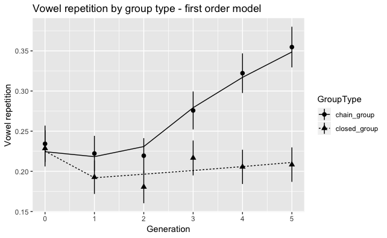

```r
ggplot(df_director, aes(Generation, CandV, shape=GroupType)) +
  stat_summary(fun.data=mean_se, geom="pointrange") +
  stat_summary(aes(y=fitted(CandV_first_order), linetype=GroupType),
               fun.y=mean, geom="line") +
  ylab("Vowel repetition")+
  ggtitle('Vowel repetition by group type - first order model')
```

```r
dev.print(pdf, 'Vowel repetition by group type - first order model.pdf')
```

## 10.2 CandV: Plots showing model fit of 1st model by lexicon type

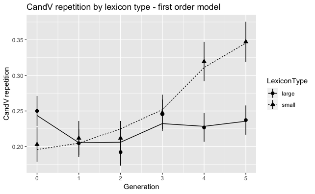

```r
ggplot(df_director, aes(Generation, CandV, shape=LexiconType)) +
  stat_summary(fun.data=mean_se, geom="pointrange") +
  stat_summary(aes(y=fitted(CandV_first_order), linetype=LexiconType),
               fun.y=mean, geom="line") +
  ylab("CandV repetition") +
  ggtitle('CandV repetition by lexicon type - first order model')
```

```r
dev.print(pdf,'CandV repetition by lexicon type - first order model.pdf')
```

# 11 Analysis of adjacent syllable repetition

## 11.1 Descriptive plot

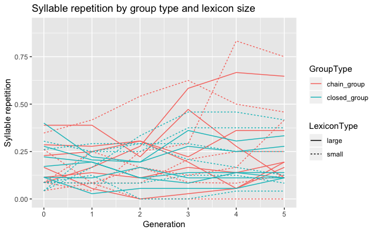

```r
ggplot(df_director_plot, aes(Generation, SyllableRepetition, group = group_id, colour=GroupType, linetype=LexiconType)) +
  stat_summary(fun.data=mean_se, geom="line") +
  ylab("Syllable repetition")+
  ggtitle('Syllable repetition by group type and lexicon size')
```

```r
dev.print(pdf, 'Syllable repetition by group type - dog dinner.pdf')
```

## 11.2 Syllable repetition: Full models

```r
# ADJ_third_order <- glmer(SyllableRepetition ~ #maximal random effect structure, up to cubic term
#                   (ot1+ot2+ot3) * GroupType * LexiconType + (1+ot1+ot2+ot3|Unique_Participant) +
#                   (1+ot1+ot2+ot3 |Meaning) + (1+ot1+ot2+ot3|Pair), data=df_director, family=binomial,
#                   control=glmerControl(optimizer = "bobyqa", optCtrl=list(maxfun=1e5)))
# ADJ_second_order <- glmer(SyllableRepetition ~ #maximal random effect structure, up to quadratic term
#                   (ot1+ot2) * GroupType * LexiconType + (1+ot1+ot2|Unique_Participant) +
#                   (1+ot1+ot2 |Meaning) + (1+ot1+ot2|Pair),
#                   data=df_director, family=binomial,
#                   control=glmerControl(optimizer = "bobyqa", optCtrl=list(maxfun=1e5)))
# ADJ_first_order <- glmer(SyllableRepetition ~ #maximal random effect structure, up to linear term
#                   ot1 * GroupType * LexiconType + (1+ot1|Unique_Participant) +
#                   (1+ot1 |Meaning) + (1+ot1|Pair), data=df_director, family=binomial,
#                   control=glmerControl(optimizer = "bobyqa", optCtrl=list(maxfun=1e5)))
```

## 11.3 Syllable repetition: Reduced models

The full models above also result in singular fit. So they are reduced below.

```r
ADJ_third_order <- glmer(SyllableRepetition ~ #maximal random effect structure, up to cubic term
                         (ot1+ot2+ot3) * GroupType * LexiconType + (1|Unique_Participant) +
                           (1|Meaning), data=df_director, family=binomial,
                         control=glmerControl(optimizer = "bobyqa", optCtrl=list(maxfun=1e5)))
ADJ_second_order <- glmer(SyllableRepetition ~ #maximal random effect structure, up to quadratic term
                      (ot1+ot2) * GroupType * LexiconType + (1|Unique_Participant) +
                        (1|Meaning), data=df_director, family=binomial,
                      control=glmerControl(optimizer = "bobyqa", optCtrl=list(maxfun=1e5)))
ADJ_first_order <- glmer(SyllableRepetition ~ #maximal random effect structure, up to linear term
                        ot1 * GroupType * LexiconType + (1|Unique_Participant) +
                          (1|Meaning), data=df_director, family=binomial,
                        control=glmerControl(optimizer = "bobyqa", optCtrl=list(maxfun=1e5)))
summary(ADJ_third_order)
```

```
Generalized linear mixed model fit by maximum likelihood (Laplace Approximation) [
glmerMod]
 Family: binomial  ( logit )
Formula: SyllableRepetition ~ (ot1 + ot2 + ot3) * GroupType * LexiconType +
    (1 | Unique_Participant) + (1 | Meaning)
   Data: df_director
Control: glmerControl(optimizer = "bobyqa", optCtrl = list(maxfun = 1e+05))

     AIC      BIC   logLik deviance df.resid
  4150.9   4265.5  -2057.4   4114.9     4277

Scaled residuals:
    Min      1Q  Median      3Q     Max
-1.5437 -0.5200 -0.3744 -0.2349  4.3921

Random effects:
 Groups             Name        Variance Std.Dev.
 Unique_Participant (Intercept) 0.8370   0.9149
 Meaning            (Intercept) 0.1516   0.3894
Number of obs: 4295, groups:  Unique_Participant, 156; Meaning, 18

Fixed effects:
                             Estimate Std. Error z value Pr(>|z|)
(Intercept)                 -1.571936   0.141585 -11.102   <2e-16 ***
ot1                          0.413785   0.199288   2.076   0.0379 *
ot2                          0.070227   0.190396   0.369   0.7122
ot3                         -0.104004   0.163595  -0.636   0.5249
GroupType1                   0.126179   0.093707   1.347   0.1781
LexiconType1                 0.018237   0.106305   0.172   0.8638
ot1:GroupType1               0.244195   0.137434   1.777   0.0756 .
ot2:GroupType1               0.071716   0.137537   0.521   0.6021
ot3:GroupType1               0.003504   0.137651   0.025   0.9797
ot1:LexiconType1            -0.300543   0.199252  -1.508   0.1315
ot2:LexiconType1             0.155353   0.190201   0.817   0.4141
ot3:LexiconType1            -0.040213   0.163607  -0.246   0.8058
GroupType1:LexiconType1      0.065018   0.093615   0.695   0.4874
ot1:GroupType1:LexiconType1 -0.034759   0.137430  -0.253   0.8003
ot2:GroupType1:LexiconType1 -0.181267   0.137397  -1.319   0.1871
ot3:GroupType1:LexiconType1  0.047082   0.137658   0.342   0.7323
---
Signif. codes:  0 ‘***’ 0.001 ‘**’ 0.01 ‘*’ 0.05 ‘.’ 0.1 ‘ ’ 1
```

```
Correlation matrix not shown by default, as p = 16 > 12.
Use print(x, correlation=TRUE)  or
    vcov(x)        if you need it
```

```r
summary(ADJ_second_order)
```

```
Generalized linear mixed model fit by maximum likelihood (Laplace Approximation) [
glmerMod]
 Family: binomial  ( logit )
Formula: SyllableRepetition ~ (ot1 + ot2) * GroupType * LexiconType +
    (1 | Unique_Participant) + (1 | Meaning)
   Data: df_director
Control: glmerControl(optimizer = "bobyqa", optCtrl = list(maxfun = 1e+05))

     AIC      BIC   logLik deviance df.resid
  4143.6   4232.8  -2057.8   4115.6     4281

Scaled residuals:
    Min      1Q  Median      3Q     Max
-1.5325 -0.5195 -0.3756 -0.2343  4.2787

Random effects:
 Groups             Name        Variance Std.Dev.
 Unique_Participant (Intercept) 0.8404   0.9167
 Meaning            (Intercept) 0.1516   0.3894
Number of obs: 4295, groups:  Unique_Participant, 156; Meaning, 18

Fixed effects:
                            Estimate Std. Error z value Pr(>|z|)
(Intercept)                 -1.57245    0.14076 -11.171  < 2e-16 ***
ot1                          0.47557    0.17671   2.691  0.00712 **
ot2                          0.01083    0.16934   0.064  0.94901
GroupType1                   0.11267    0.08954   1.258  0.20831
LexiconType1                 0.02332    0.10526   0.222  0.82465
ot1:GroupType1               0.23088    0.13579   1.700  0.08908 .
ot2:GroupType1               0.08368    0.13625   0.614  0.53914
ot1:LexiconType1            -0.25764    0.17671  -1.458  0.14485
ot2:LexiconType1             0.11579    0.16934   0.684  0.49410
GroupType1:LexiconType1      0.04980    0.08940   0.557  0.57750
ot1:GroupType1:LexiconType1 -0.04140    0.13577  -0.305  0.76042
ot2:GroupType1:LexiconType1 -0.17256    0.13605  -1.268  0.20467
---
Signif. codes:  0 ‘***’ 0.001 ‘**’ 0.01 ‘*’ 0.05 ‘.’ 0.1 ‘ ’ 1

Correlation of Fixed Effects:
            (Intr) ot1    ot2    GrpTy1 LxcnT1 ot1:GT1 ot2:GT1 o1:LT1 o2:LT1 GT1:LT
```

[output cut: 8 more lines]

```
GrpTyp1:LT1  0.007  0.015 -0.005 -0.067 -0.487  0.032  -0.024  -0.028  0.014
ot1:GT1:LT1  0.003 -0.015  0.009  0.032 -0.262 -0.133   0.038   0.217  0.124  0.364
ot2:GT1:LT1  0.010  0.006 -0.019 -0.023  0.221  0.038  -0.121   0.119  0.259 -0.350
            o1:GT1:
ot1
ot2
GroupType1
LexiconTyp1
ot1:GrpTyp1
ot2:GrpTyp1
ot1:LxcnTy1
ot2:LxcnTy1
GrpTyp1:LT1
ot1:GT1:LT1
ot2:GT1:LT1 -0.008
```

```r
summary(ADJ_first_order)
```

```
Generalized linear mixed model fit by maximum likelihood (Laplace Approximation) [
glmerMod]
 Family: binomial  ( logit )
Formula:
SyllableRepetition ~ ot1 * GroupType * LexiconType + (1 | Unique_Participant) +
    (1 | Meaning)
   Data: df_director
Control: glmerControl(optimizer = "bobyqa", optCtrl = list(maxfun = 1e+05))

     AIC      BIC   logLik deviance df.resid
  4138.5   4202.2  -2059.3   4118.5     4285

Scaled residuals:
    Min      1Q  Median      3Q     Max
-1.5408 -0.5184 -0.3770 -0.2370  4.4456

Random effects:
 Groups             Name        Variance Std.Dev.
 Unique_Participant (Intercept) 0.8516   0.9228
 Meaning            (Intercept) 0.1516   0.3894
Number of obs: 4295, groups:  Unique_Participant, 156; Meaning, 18

Fixed effects:
                            Estimate Std. Error z value Pr(>|z|)
(Intercept)                 -1.58205    0.13926 -11.361  < 2e-16 ***
ot1                          0.46073    0.15839   2.909  0.00363 **
GroupType1                   0.12461    0.08317   1.498  0.13404
LexiconType1                 0.04613    0.10298   0.448  0.65417
ot1:GroupType1               0.23864    0.13492   1.769  0.07695 .
ot1:LexiconType1            -0.15288    0.15858  -0.964  0.33500
GroupType1:LexiconType1      0.00233    0.08338   0.028  0.97771
ot1:GroupType1:LexiconType1 -0.06429    0.13488  -0.477  0.63364
---
Signif. codes:  0 ‘***’ 0.001 ‘**’ 0.01 ‘*’ 0.05 ‘.’ 0.1 ‘ ’ 1

Correlation of Fixed Effects:
            (Intr) ot1    GrpTy1 LxcnT1 ot1:GT1 o1:LT1 GT1:LT
ot1         -0.118
GroupType1  -0.334  0.078
LexiconTyp1 -0.067  0.007  0.024
ot1:GrpTyp1 -0.205  0.317  0.384 -0.007
ot1:LxcnTy1 -0.001 -0.100  0.030 -0.155 -0.034
GrpTyp1:LT1  0.028  0.032 -0.111 -0.458  0.049   0.074
ot1:GT1:LT1 -0.002 -0.032  0.048 -0.281 -0.130   0.316  0.384
```

## 11.4 Syllable repetition: Model comparison

```r
ADJ_model.names <- c("ADJ first order","ADJ second order","ADJ third order")
ADJ_summ.table <- do.call(rbind, lapply(list(ADJ_first_order,ADJ_second_order,ADJ_third_order), broom::glance))
ADJ_table.cols <- c("df.residual", "deviance", "AIC")
ADJ_reported.table <- ADJ_summ.table[ADJ_table.cols]
names(ADJ_reported.table) <- c("Resid.Df", "Resid.Dev", "AIC")
ADJ_reported.table[['dAIC']] <-  with(ADJ_reported.table, AIC - min(AIC))
ADJ_reported.table[['AIC_weight']] <- with(ADJ_reported.table, exp(- 0.5 * dAIC) / sum(exp(- 0.5 * dAIC)))
ADJ_reported.table$AIC <- NULL
ADJ_reported.table$AIC_weight <- round(ADJ_reported.table$AIC_weight, 2)
ADJ_reported.table$dAIC <- round(ADJ_reported.table$dAIC, 1)
ADJ_reported.table$Resid.Dev <- round(ADJ_reported.table$Resid.Dev, 2)
row.names(ADJ_reported.table) <- ADJ_model.names
```

```
Setting row names on a tibble is deprecated.
```

```r
View(ADJ_reported.table)
sjPlot::tab_df(ADJ_reported.table,
               file="model comparison _ADJ.doc")
sjPlot::tab_df(round(coef(summary(ADJ_first_order)),3),file='ADJ_fixed_effects.doc')
```

## 11.5 Syllable repetition: Plots showing model fit of 1st and 2nd order models by group type

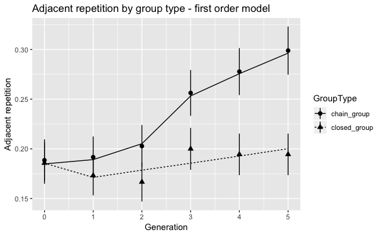

```r
df_director_adj_plots <- subset(df_director, !(is.na(df_director$SyllableRepetition)))

ggplot(df_director_adj_plots, aes(Generation, SyllableRepetition, shape=GroupType)) +
  stat_summary(fun.data=mean_se, geom="pointrange") +
  stat_summary(aes(y=fitted(ADJ_first_order), linetype=GroupType),
               fun.y=mean, geom="line") +
  ylab("Adjacent repetition")+
  ggtitle('Adjacent repetition by group type - first order model')
```

```r
dev.print(pdf,'Adjacent repetition by group type - first order model.pdf')
```

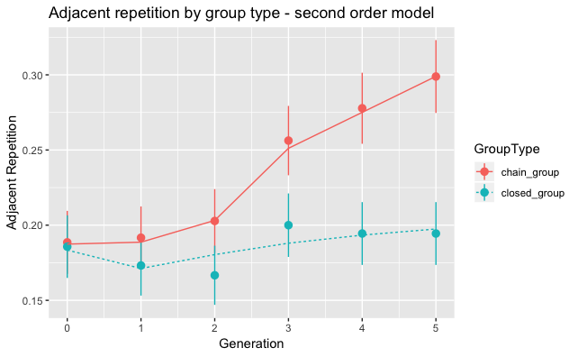

```r
ggplot(df_director_adj_plots, aes(Generation, SyllableRepetition, color=GroupType)) +
  stat_summary(fun.data=mean_se, geom="pointrange") +
  stat_summary(aes(y=fitted(ADJ_second_order), linetype=GroupType),
               fun.y=mean, geom="line") +
  ylab("Adjacent Repetition") +
  ggtitle('Adjacent repetition by group type - second order model')
```

```r
dev.print(pdf,'Adjacent repetition by group type - second order model.pdf')
```

## 11.6 Syllable repetition: Plots showing model fit of 1st and 2nd order models by lexicon type

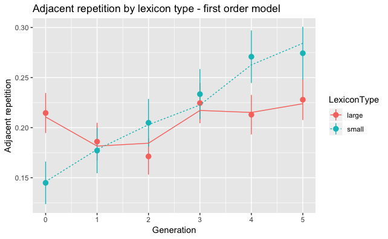

```r
ggplot(df_director_adj_plots, aes(Generation, SyllableRepetition, color=LexiconType)) +
  stat_summary(fun.data=mean_se, geom="pointrange") +
  stat_summary(aes(y=fitted(ADJ_first_order), linetype=LexiconType),
               fun.y=mean, geom="line") +
  ylab("Adjacent repetition")+
  ggtitle('Adjacent repetition by lexicon type - first order model')
```

```r
dev.print(pdf,'Adjacent repetition by lexicon type - first order model.pdf')
```

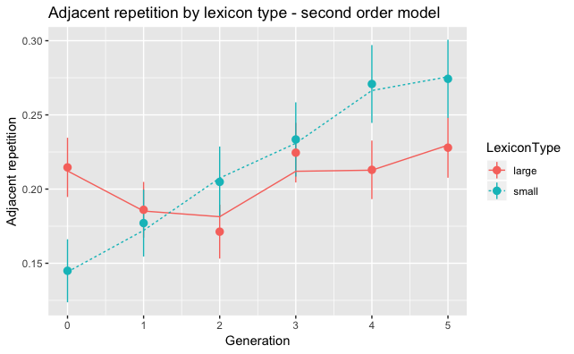

```r
ggplot(df_director_adj_plots, aes(Generation, SyllableRepetition, color=LexiconType)) +
  stat_summary(fun.data=mean_se, geom="pointrange") +
  stat_summary(aes(y=fitted(ADJ_second_order), linetype=LexiconType),
               fun.y=mean, geom="line") +
  ylab("Adjacent repetition")+
  ggtitle('Adjacent repetition by lexicon type - second order model')
```

```r
dev.print(pdf,'Adjacent repetition by lexicon type - second order model.pdf')
```

# 12 Accuracy

## 12.1 Descriptive plot

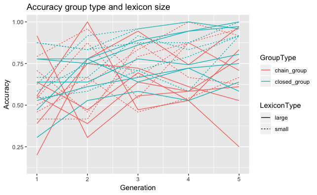

```r
groups2 = ddply(df_matcher, c("GroupType", "LexiconType", "GroupNumber"), summarise, n=length(Block))
groups2$group_id = factor(LETTERS[1:24])
df_matcher_plot = merge(df_matcher, groups, all.x = TRUE)
ggplot(df_matcher_plot, aes(Generation, Score, group = group_id, colour=GroupType, linetype=LexiconType)) +
  stat_summary(fun.data=mean_se, geom="line") +
  ylab("Accuracy")+
  ggtitle('Accuracy group type and lexicon size')
```

```r
dev.print(pdf, 'Accuracy by group type - dog dinner.pdf')
```

## 12.2 Accuracy: Full models

```r
#ACC_first_order <- glmer(Score ~ #maximal random effect structure, up to linear term
#                        ot1 * GroupType * LexiconType  + (1+ot1|Unique_Participant) +
#                       (1+ot1 |Meaning) + (1+ot1|Pair), data=df_matcher, family=binomial,
#                       control=glmerControl(optimizer = "bobyqa", optCtrl=list(maxfun=1e5)))
#ACC_second_order <- glmer(Score ~ #maximal random effect structure, up to quadratic term
#                     (ot1+ot2) * GroupType * LexiconType + (1+ot1+ot2|Unique_Participant) +
#                     (1+ot1+ot2 |Meaning) + (1+ot1+ot2|Pair), data=df_matcher, family=binomial,
#                     control=glmerControl(optimizer = "bobyqa", optCtrl=list(maxfun=1e5)))
#ACC_third_order <- glmer(Score ~ #maximal random effect structure, up to cubic term
#                     (ot1+ot2+ot3) * GroupType * LexiconType + (1+ot1+ot2+ot3|Unique_Participant) +
#                   (1+ot1+ot2+ot3 |Meaning) + (1+ot1+ot2+ot3|Pair), data=df_matcher, family=binomial,
#                   control=glmerControl(optimizer = "bobyqa", optCtrl=list(maxfun=1e5)))
```

## 12.3 Accuracy: Reduced models

The full models above also result in singular fit. So they are reduced below.

```r
ACC_first_order <- glmer(Score ~ #maximal random effect structure, up to linear term
                         ot1 * GroupType * LexiconType + (1|Unique_Participant) + (1|Meaning),
                       data=df_matcher, family=binomial,
                       control=glmerControl(optimizer = "bobyqa", optCtrl=list(maxfun=1e5)))
ACC_second_order <- glmer(Score ~ #maximal random effect structure, up to quadratic term
                      (ot1+ot2) * GroupType * LexiconType + (1|Unique_Participant) + (1|Meaning),
                    data=df_matcher, family=binomial,
                    control=glmerControl(optimizer = "bobyqa", optCtrl=list(maxfun=1e5)))
ACC_third_order <- glmer(Score ~ #maximal random effect structure, up to cubic term
                      (ot1+ot2+ot3) * GroupType * LexiconType + (1|Unique_Participant) + (1|Meaning),
                    data=df_matcher, family=binomial,
                    control=glmerControl(optimizer = "bobyqa", optCtrl=list(maxfun=1e5)))
summary(ACC_third_order)
```

```
Generalized linear mixed model fit by maximum likelihood (Laplace Approximation) [
glmerMod]
 Family: binomial  ( logit )
Formula:
Score ~ (ot1 + ot2 + ot3) * GroupType * LexiconType + (1 | Unique_Participant) +
    (1 | Meaning)
   Data: df_matcher
Control: glmerControl(optimizer = "bobyqa", optCtrl = list(maxfun = 1e+05))

     AIC      BIC   logLik deviance df.resid
  4070.5   4181.9  -2017.3   4034.5     3575

Scaled residuals:
    Min      1Q  Median      3Q     Max
-6.1190 -0.9143  0.4321  0.6505  1.5580

Random effects:
 Groups             Name        Variance Std.Dev.
 Unique_Participant (Intercept) 0.55055  0.7420
 Meaning            (Intercept) 0.03745  0.1935
Number of obs: 3593, groups:  Unique_Participant, 144; Meaning, 18

Fixed effects:
                            Estimate Std. Error z value Pr(>|z|)
(Intercept)                  1.10906    0.10614  10.449  < 2e-16 ***
ot1                          0.88270    0.12588   7.012 2.35e-12 ***
ot2                         -0.09864    0.12379  -0.797 0.425558
ot3                          0.10352    0.12181   0.850 0.395405
GroupType1                  -0.31792    0.09418  -3.376 0.000736 ***
LexiconType1                -0.32208    0.09513  -3.386 0.000710 ***
ot1:GroupType1              -0.28119    0.12573  -2.236 0.025322 *
ot2:GroupType1              -0.11101    0.12379  -0.897 0.369854
ot3:GroupType1              -0.04318    0.12180  -0.355 0.722946
ot1:LexiconType1            -0.31164    0.12576  -2.478 0.013209 *
ot2:LexiconType1            -0.07789    0.12379  -0.629 0.529213
ot3:LexiconType1             0.06388    0.12182   0.524 0.600049
GroupType1:LexiconType1      0.08920    0.09413   0.948 0.343319
ot1:GroupType1:LexiconType1  0.02448    0.12572   0.195 0.845639
ot2:GroupType1:LexiconType1  0.12381    0.12379   1.000 0.317238
ot3:GroupType1:LexiconType1  0.16946    0.12183   1.391 0.164259
---
Signif. codes:  0 ‘***’ 0.001 ‘**’ 0.01 ‘*’ 0.05 ‘.’ 0.1 ‘ ’ 1
```

```
Correlation matrix not shown by default, as p = 16 > 12.
Use print(x, correlation=TRUE)  or
    vcov(x)        if you need it
```

```r
summary(ACC_second_order)
```

```
Generalized linear mixed model fit by maximum likelihood (Laplace Approximation) [
glmerMod]
 Family: binomial  ( logit )
Formula: Score ~ (ot1 + ot2) * GroupType * LexiconType + (1 | Unique_Participant) +
    (1 | Meaning)
   Data: df_matcher
Control: glmerControl(optimizer = "bobyqa", optCtrl = list(maxfun = 1e+05))

     AIC      BIC   logLik deviance df.resid
  4065.3   4151.9  -2018.7   4037.3     3579

Scaled residuals:
    Min      1Q  Median      3Q     Max
-5.6764 -0.9113  0.4319  0.6498  1.6065

Random effects:
 Groups             Name        Variance Std.Dev.
 Unique_Participant (Intercept) 0.55588  0.7456
 Meaning            (Intercept) 0.03741  0.1934
Number of obs: 3593, groups:  Unique_Participant, 144; Meaning, 18

Fixed effects:
                            Estimate Std. Error z value Pr(>|z|)
(Intercept)                  1.10628    0.10634  10.403  < 2e-16 ***
ot1                          0.87276    0.12473   6.997 2.61e-12 ***
ot2                         -0.11617    0.12191  -0.953 0.340617
GroupType1                  -0.31668    0.09441  -3.354 0.000796 ***
LexiconType1                -0.32036    0.09537  -3.359 0.000781 ***
ot1:GroupType1              -0.27350    0.12458  -2.195 0.028134 *
ot2:GroupType1              -0.08912    0.12190  -0.731 0.464743
ot1:LexiconType1            -0.30254    0.12461  -2.428 0.015183 *
ot2:LexiconType1            -0.06219    0.12190  -0.510 0.609955
GroupType1:LexiconType1      0.08662    0.09437   0.918 0.358681
ot1:GroupType1:LexiconType1  0.01577    0.12457   0.127 0.899269
ot2:GroupType1:LexiconType1  0.10388    0.12190   0.852 0.394120
---
Signif. codes:  0 ‘***’ 0.001 ‘**’ 0.01 ‘*’ 0.05 ‘.’ 0.1 ‘ ’ 1

Correlation of Fixed Effects:
            (Intr) ot1    ot2    GrpTy1 LxcnT1 ot1:GT1 ot2:GT1 o1:LT1 o2:LT1 GT1:LT
```

[output cut: 8 more lines]

```
GrpTyp1:LT1  0.031  0.042  0.023 -0.079 -0.559 -0.065  -0.018  -0.056 -0.021
ot1:GT1:LT1  0.035  0.111  0.063 -0.065 -0.055 -0.234  -0.082   0.245 -0.072  0.083
ot2:GT1:LT1  0.022  0.063  0.079 -0.018 -0.021 -0.082  -0.202  -0.072  0.296  0.019
            o1:GT1:
ot1
ot2
GroupType1
LexiconTyp1
ot1:GrpTyp1
ot2:GrpTyp1
ot1:LxcnTy1
ot2:LxcnTy1
GrpTyp1:LT1
ot1:GT1:LT1
ot2:GT1:LT1  0.112
```

```r
summary(ACC_first_order)
```

```
Generalized linear mixed model fit by maximum likelihood (Laplace Approximation) [
glmerMod]
 Family: binomial  ( logit )
Formula: Score ~ ot1 * GroupType * LexiconType + (1 | Unique_Participant) +
    (1 | Meaning)
   Data: df_matcher
Control: glmerControl(optimizer = "bobyqa", optCtrl = list(maxfun = 1e+05))

     AIC      BIC   logLik deviance df.resid
  4060.2   4122.1  -2020.1   4040.2     3583

Scaled residuals:
    Min      1Q  Median      3Q     Max
-5.3773 -0.9108  0.4328  0.6502  1.6203

Random effects:
 Groups             Name        Variance Std.Dev.
 Unique_Participant (Intercept) 0.56201  0.7497
 Meaning            (Intercept) 0.03734  0.1932
Number of obs: 3593, groups:  Unique_Participant, 144; Meaning, 18

Fixed effects:
                             Estimate Std. Error z value Pr(>|z|)
(Intercept)                  1.105108   0.106587  10.368  < 2e-16 ***
ot1                          0.870556   0.123001   7.078 1.47e-12 ***
GroupType1                  -0.314923   0.094714  -3.325 0.000884 ***
LexiconType1                -0.318162   0.095662  -3.326 0.000881 ***
ot1:GroupType1              -0.263141   0.122847  -2.142 0.032192 *
ot1:LexiconType1            -0.288397   0.122878  -2.347 0.018924 *
GroupType1:LexiconType1      0.084818   0.094668   0.896 0.370279
ot1:GroupType1:LexiconType1 -0.003059   0.122841  -0.025 0.980136
---
Signif. codes:  0 ‘***’ 0.001 ‘**’ 0.01 ‘*’ 0.05 ‘.’ 0.1 ‘ ’ 1

Correlation of Fixed Effects:
            (Intr) ot1    GrpTy1 LxcnT1 ot1:GT1 o1:LT1 GT1:LT
ot1          0.074
GroupType1  -0.500 -0.046
LexiconTyp1 -0.090 -0.058  0.031
ot1:GrpTyp1 -0.041  0.293  0.077  0.030
ot1:LxcnTy1 -0.052 -0.204  0.030  0.077  0.075
GrpTyp1:LT1  0.029  0.031 -0.077 -0.559 -0.056  -0.047
ot1:GT1:LT1  0.026  0.074 -0.056 -0.046 -0.203   0.293  0.076
```

## 12.4 Accuracy: Model comparison

```r
ACC_model.names <- c("ACC first order","ACC second order","ACC third order")
ACC_summ.table <- do.call(rbind, lapply(list(ACC_first_order,ACC_second_order,ACC_third_order), broom::glance))
ACC_table.cols <- c("df.residual", "deviance", "AIC")
ACC_reported.table <- ACC_summ.table[ACC_table.cols]
names(ACC_reported.table) <- c("Resid.Df", "Resid.Dev", "AIC")
ACC_reported.table[['dAIC']] <-  with(ACC_reported.table, AIC - min(AIC))
ACC_reported.table[['AIC_weight']] <- with(ACC_reported.table, exp(- 0.5 * dAIC) / sum(exp(- 0.5 * dAIC)))
ACC_reported.table$AIC <- NULL
ACC_reported.table$dAIC <- round(ACC_reported.table$dAIC, 1)
ACC_reported.table$AIC_weight <- round(ACC_reported.table$AIC_weight, 2)
ACC_reported.table$Resid.Dev <- round(ACC_reported.table$Resid.Dev, 2)
row.names(ACC_reported.table) <- ACC_model.names
```

```
Setting row names on a tibble is deprecated.
```

```r
View(ACC_reported.table)
sjPlot::tab_df(ACC_reported.table,
               file="model comparison _ACC.doc")
```

## 12.5 Accuracy: Plots showing model fit of 1st and 2nd order models by group type

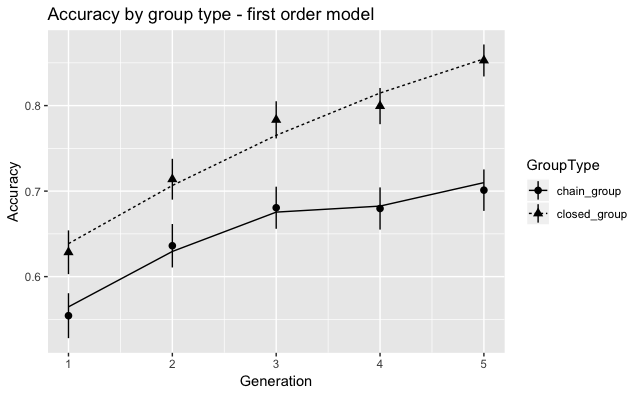

```r
ggplot(df_matcher, aes(Generation, Score, shape=GroupType)) +
  stat_summary(fun.data=mean_se, geom="pointrange") +
  stat_summary(aes(y=fitted(ACC_first_order), linetype=GroupType),
               fun.y=mean, geom="line") +
  ylab("Accuracy")+
  ggtitle('Accuracy by group type - first order model')
```

```r
dev.print(pdf,'Accuracy by group type - first order model.pdf')
```

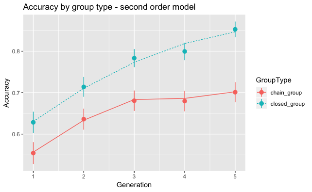

```r
ggplot(df_matcher, aes(Generation, Score, color=GroupType)) +
  stat_summary(fun.data=mean_se, geom="pointrange") +
  stat_summary(aes(y=fitted(ACC_second_order), linetype=GroupType),
               fun.y=mean, geom="line") +
  ylab("Accuracy")+
  ggtitle('Accuracy by group type - second order model')
```

```r
dev.print(pdf,'Accuracy by group type - second order model.pdf')
```

## 12.6 Accuracy: Plots showing model fit of 1st and 2nd order models by lexicon type

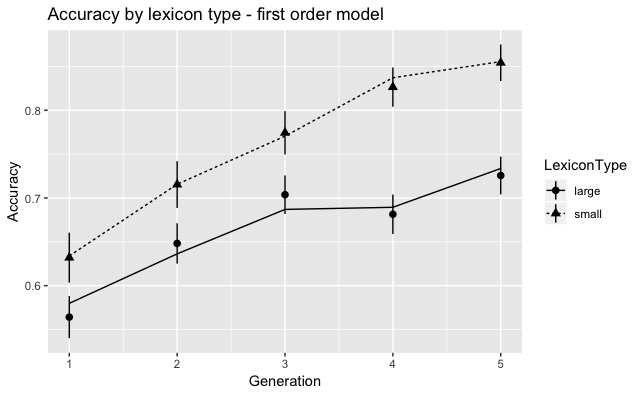

```r
ggplot(df_matcher, aes(Generation, Score, shape=LexiconType)) +
  stat_summary(fun.data=mean_se, geom="pointrange") +
  stat_summary(aes(y=fitted(ACC_first_order), linetype=LexiconType),
               fun.y=mean, geom="line") +
  ylab("Accuracy")+
  ggtitle('Accuracy by lexicon type - first order model')
```

```r
dev.print(pdf,'Accuracy by lexicon type - first order model.pdf')
```

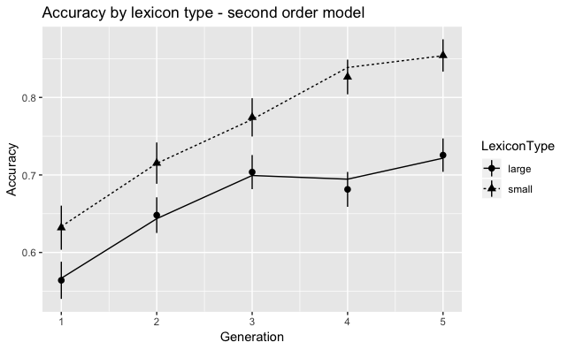

```r
ggplot(df_matcher, aes(Generation, Score, shape=LexiconType)) +
  stat_summary(fun.data=mean_se, geom="pointrange") +
  stat_summary(aes(y=fitted(ACC_second_order), linetype=LexiconType),
               fun.y=mean, geom="line") +
  ylab("Accuracy")+
  ggtitle('Accuracy by lexicon type - second order model')
```

```r
dev.print(pdf,'Accuracy by lexicon type - second order model.pdf')
```

```r
sjPlot::tab_df(round(coef(summary(ACC_first_order)),3),file='ACC_fixed_effects.doc')
```

# 13 Homonymy

## 13.1 Coding homonymy

These are based on iteration 2 only. Homonymy is calculated as proportions.

```r
df_homonymy<-setNames(aggregate(df_director_generations_1_to_5$ConsonantRepetition, by=list(df_director_generations_1_to_5$GroupType,df_director_generations_1_to_5$LexiconType,df_director_generations_1_to_5$GroupNumber,df_director_generations_1_to_5$Generation,df_director_generations_1_to_5$Unique_language,df_director_generations_1_to_5$Pair, df_director_generations_1_to_5$Unique_Participant), FUN=mean),c('GroupType','LexiconType','GroupNumber','Generation','Unique_language','Pair', 'Unique_Participant','ConsonantRepetition_mean'))
df_homonymy$Word_repetition<-NA
for(i in unique(df_homonymy$Unique_language)){
  subs_ <- subset(df_director_generations_1_to_5,Unique_language==i)
  for(j in 1:nrow(df_homonymy)){
    if(toString(df_homonymy[j,]$Unique_language) == i){
      df_homonymy[j,]$Word_repetition <- (length(subs_$TypedLabel)-length(unique(subs_$TypedLabel)))/length(subs_$TypedLabel)

    }
  }
}
initial_languages<-subset(df_director,Generation==0)
df_initial_languages <-setNames(aggregate(initial_languages$ConsonantRepetition, by=list(initial_languages$GroupType,initial_languages$LexiconType,initial_languages$GroupNumber,initial_languages$Generation,initial_languages$Unique_language,initial_languages$Pair, initial_languages$Unique_Participant), FUN=mean),c('GroupType','LexiconType','GroupNumber','Generation','Unique_language','Pair', 'Unique_Participant','ConsonantRepetition_mean'))
df_initial_languages$Word_repetition <-0
df_homonymy<-rbind(df_initial_languages,df_homonymy)
df_homonymy_1_to_5 <- subset(df_homonymy, Generation>0) #generations 1 to 5
cor(df_homonymy_1_to_5$ConsonantRepetition_mean,df_homonymy_1_to_5$Word_repetition) #looking at mean CVC redup. When looking at sum CVC redup the correlation was .20...
```

```
[1] 0.1522067
```

```r
df_homonymy$timebin = df_homonymy$Generation + 1
t_ = poly(unique(df_homonymy$timebin), 3)
df_homonymy[,paste("ot", 1:3, sep="")] <- t_[df_homonymy$timebin, 1:3]
contrasts(df_homonymy$LexiconType) = contr.sum(2)
contrasts(df_homonymy$GroupType) = contr.sum(2)
```

## 13.2 Homonymy: Models

Can’t fit a 3rd order model because there are fewer observations than random effects

```r
homonymy_first_order <- lmer(Word_repetition ~
                          ot1*GroupType*LexiconType +
                          (1|Unique_Participant),
                        data=df_homonymy, control=lmerControl(optimizer = "bobyqa", optCtrl=list(maxfun=2e5)))
homonymy_second_order <- lmer(Word_repetition ~
                          (ot1+ot2)*GroupType*LexiconType +
                            (1|Unique_Participant),
                        data=df_homonymy, control=lmerControl(optimizer = "bobyqa", optCtrl=list(maxfun=2e5)))
summary(homonymy_first_order)
```

```
Linear mixed model fit by REML. t-tests use Satterthwaite's method ['lmerModLmerTest']
Formula: Word_repetition ~ ot1 * GroupType * LexiconType + (1 | Unique_Participant)
   Data: df_homonymy
Control: lmerControl(optimizer = "bobyqa", optCtrl = list(maxfun = 2e+05))

REML criterion at convergence: -703.9

Scaled residuals:
    Min      1Q  Median      3Q     Max
-3.5127 -0.3283 -0.0729  0.2178  2.9316

Random effects:
 Groups             Name        Variance Std.Dev.
 Unique_Participant (Intercept) 0.007011 0.08373
 Residual                       0.001270 0.03563
Number of obs: 288, groups:  Unique_Participant, 156

Fixed effects:
                              Estimate Std. Error         df t value Pr(>|t|)
(Intercept)                  6.748e-02  8.337e-03  1.377e+02   8.094 2.72e-13 ***
ot1                          1.569e-02  1.073e-02  2.608e+02   1.461 0.145125
GroupType1                   3.702e-02  6.036e-03  2.221e+02   6.134 3.89e-09 ***
LexiconType1                -1.986e-03  8.337e-03  1.377e+02  -0.238 0.812108
ot1:GroupType1               5.999e-02  9.480e-03  2.158e+02   6.328 1.41e-09 ***
ot1:LexiconType1             3.875e-02  1.073e-02  2.608e+02   3.610 0.000367 ***
GroupType1:LexiconType1      1.279e-04  6.036e-03  2.221e+02   0.021 0.983113
ot1:GroupType1:LexiconType1 -2.160e-03  9.480e-03  2.158e+02  -0.228 0.819961
---
Signif. codes:  0 ‘***’ 0.001 ‘**’ 0.01 ‘*’ 0.05 ‘.’ 0.1 ‘ ’ 1

Correlation of Fixed Effects:
            (Intr) ot1    GrpTy1 LxcnT1 ot1:GT1 o1:LT1 GT1:LT
ot1         -0.278
GroupType1  -0.497  0.373
LexiconTyp1  0.000  0.000  0.000
ot1:GrpTyp1 -0.400  0.586  0.664  0.000
ot1:LxcnTy1  0.000  0.000  0.000 -0.278  0.000
GrpTyp1:LT1  0.000  0.000  0.000 -0.497  0.000   0.373
ot1:GT1:LT1  0.000  0.000  0.000 -0.400  0.000   0.586  0.664
```

```r
summary(homonymy_second_order)
```

```
Linear mixed model fit by REML. t-tests use Satterthwaite's method ['lmerModLmerTest']
Formula: Word_repetition ~ (ot1 + ot2) * GroupType * LexiconType + (1 |
    Unique_Participant)
   Data: df_homonymy
Control: lmerControl(optimizer = "bobyqa", optCtrl = list(maxfun = 2e+05))

REML criterion at convergence: -675.9

Scaled residuals:
    Min      1Q  Median      3Q     Max
-3.4914 -0.3467 -0.0484  0.1948  2.9093

Random effects:
 Groups             Name        Variance Std.Dev.
 Unique_Participant (Intercept) 0.007015 0.08375
 Residual                       0.001290 0.03592
Number of obs: 288, groups:  Unique_Participant, 156

Fixed effects:
                              Estimate Std. Error         df t value Pr(>|t|)
(Intercept)                  6.416e-02  8.796e-03  1.221e+02   7.294 3.31e-11 ***
ot1                          1.466e-02  1.207e-02  2.666e+02   1.214  0.22579
ot2                         -9.013e-03  1.175e-02  2.607e+02  -0.767  0.44386
GroupType1                   4.093e-02  7.005e-03  1.665e+02   5.843 2.62e-08 ***
LexiconType1                -1.448e-03  8.796e-03  1.221e+02  -0.165  0.86950
ot1:GroupType1               5.890e-02  9.616e-03  2.120e+02   6.125 4.35e-09 ***
ot2:GroupType1              -1.139e-02  9.681e-03  2.092e+02  -1.176  0.24086
ot1:LexiconType1             3.702e-02  1.207e-02  2.666e+02   3.066  0.00239 **
ot2:LexiconType1             4.773e-03  1.175e-02  2.607e+02   0.406  0.68499
GroupType1:LexiconType1     -9.357e-05  7.005e-03  1.665e+02  -0.013  0.98936
ot1:GroupType1:LexiconType1 -1.561e-03  9.616e-03  2.120e+02  -0.162  0.87117
ot2:GroupType1:LexiconType1  1.477e-03  9.681e-03  2.092e+02   0.153  0.87889
---
Signif. codes:  0 ‘***’ 0.001 ‘**’ 0.01 ‘*’ 0.05 ‘.’ 0.1 ‘ ’ 1

Correlation of Fixed Effects:
            (Intr) ot1    ot2    GrpTy1 LxcnT1 ot1:GT1 ot2:GT1 o1:LT1 o2:LT1 GT1:LT
ot1         -0.203
ot2          0.191 -0.295
GroupType1  -0.558  0.166 -0.156
LexiconTyp1  0.000  0.000  0.000  0.000
ot1:GrpTyp1 -0.346  0.468  0.152  0.543  0.000
ot2:GrpTyp1  0.313  0.147  0.505 -0.492  0.000  0.073
ot1:LxcnTy1  0.000  0.000  0.000  0.000 -0.203  0.000   0.000
ot2:LxcnTy1  0.000  0.000  0.000  0.000  0.191  0.000   0.000  -0.295
GrpTyp1:LT1  0.000  0.000  0.000  0.000 -0.558  0.000   0.000   0.166 -0.156
ot1:GT1:LT1  0.000  0.000  0.000  0.000 -0.346  0.000   0.000   0.468  0.152  0.543
ot2:GT1:LT1  0.000  0.000  0.000  0.000  0.313  0.000   0.000   0.147  0.505 -0.492
            o1:GT1:
ot1
ot2
GroupType1
LexiconTyp1
ot1:GrpTyp1
ot2:GrpTyp1
ot1:LxcnTy1
ot2:LxcnTy1
GrpTyp1:LT1
ot1:GT1:LT1
ot2:GT1:LT1  0.073
```

## 13.3 Homonymy: Model comparison

```r
homonyms_model.names <- c("Homonymy first order","Homonymy second order")
homonyms_summ.table <- do.call(rbind, lapply(list(homonymy_first_order,homonymy_second_order), broom::glance))
homonyms_table.cols <- c("df.residual", "deviance", "AIC")
homonyms_reported.table <- homonyms_summ.table[homonyms_table.cols]
names(homonyms_reported.table) <- c("Resid. Df", "Resid.Dev", "AIC")
homonyms_reported.table[['dAIC']] <-  with(homonyms_reported.table, AIC - min(AIC))
homonyms_reported.table[['AIC_weight']] <- with(homonyms_reported.table, exp(- 0.5 * dAIC) / sum(exp(- 0.5 * dAIC)))
homonyms_reported.table$AIC <- NULL
homonyms_reported.table$AIC_weight <- round(homonyms_reported.table$AIC_weight, 2)
homonyms_reported.table$dAIC <- round(homonyms_reported.table$dAIC, 1)
homonyms_reported.table$Resid.Dev <- round(homonyms_reported.table$Resid.Dev, 2)
row.names(homonyms_reported.table) <- homonyms_model.names
```

```
Setting row names on a tibble is deprecated.
```

```r
View(homonyms_reported.table)
anova(homonymy_first_order,homonymy_second_order)
```

```
refitting model(s) with ML (instead of REML)
```

```
Data: df_homonymy
Models:
homonymy_first_order: Word_repetition ~ ot1 * GroupType * LexiconType + (1 | Unique_Participant)
homonymy_second_order: Word_repetition ~ (ot1 + ot2) * GroupType * LexiconType + (1 |
homonymy_second_order:     Unique_Participant)
                      Df     AIC     BIC logLik deviance  Chisq Chi Df Pr(>Chisq)
homonymy_first_order  10 -748.29 -711.66 384.14  -768.29
homonymy_second_order 14 -741.94 -690.66 384.97  -769.94 1.6529      4     0.7993
```

```r
sjPlot::tab_df(homonyms_reported.table,
               file="model comparison homonyms_.doc")
sjPlot::tab_df(round(coef(summary(homonymy_first_order)),3),file='homonyms_fixed_effects.doc')
```

## 13.4 Homonymy: Plots showing model fit of 1st and 2nd order models by group type

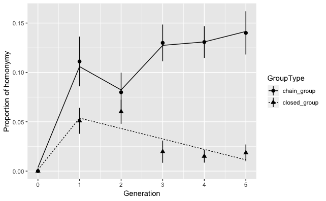

```r
ggplot(df_homonymy, aes(Generation, Word_repetition, shape=GroupType)) +
  stat_summary(fun.data=mean_se, geom="pointrange") +
  stat_summary(aes(y=fitted(homonymy_first_order), linetype=GroupType),
               fun.y=mean, geom="line") +
  ylab("Proportion of homonymy")
```

```r
dev.print(pdf,'Homonymy by group type - first order model.pdf')
```

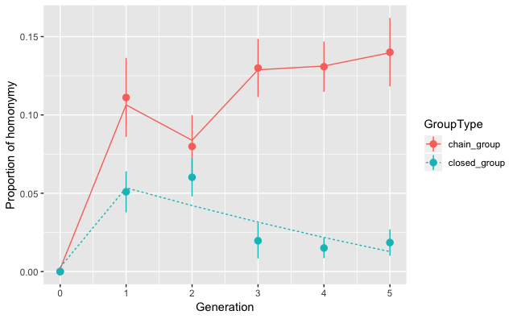

```r
ggplot(df_homonymy, aes(Generation, Word_repetition, color=GroupType)) +
  stat_summary(fun.data=mean_se, geom="pointrange") +
  stat_summary(aes(y=fitted(homonymy_second_order), linetype=GroupType),
               fun.y=mean, geom="line") +
  ylab("Proportion of homonymy")
```

```r
dev.print(pdf,'Homonymy by group type - second order model.pdf')
```

## 13.5 Homonymy: Plots showing model fit of 1st and 2nd order models by lexicon type

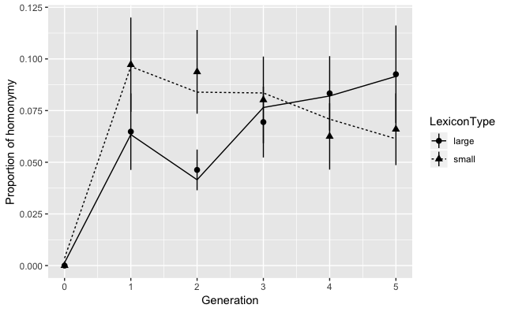

```r
ggplot(df_homonymy, aes(Generation, Word_repetition, shape=LexiconType)) +
  stat_summary(fun.data=mean_se, geom="pointrange") +
  stat_summary(aes(y=fitted(homonymy_first_order), linetype=LexiconType),
               fun.y=mean, geom="line") +
  ylab("Proportion of homonymy")
```

```r
dev.print(pdf,'Homonymy by lexicon type - first order model.pdf')
```

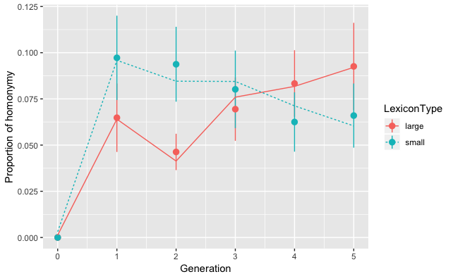

```r
ggplot(df_homonymy, aes(Generation, Word_repetition, color=LexiconType)) +
  stat_summary(fun.data=mean_se, geom="pointrange") +
  stat_summary(aes(y=fitted(homonymy_second_order), linetype=LexiconType),
               fun.y=mean, geom="line") +
  ylab("Proportion of homonymy")
```

```r
dev.print(pdf,'Homonymy by lexicon type - second order model.pdf')
```

# 14 Homonymy: Logistic analysis

Analyze homonymy again, using 0/1 coding for word repetition and binomial stats

## 14.1 Homonymy (log): Models

```r
df_homonymy$Word_repetition_binary = ifelse(df_homonymy$Word_repetition > 0, 1, 0)
homonymy_first_order_log <- glmer(Word_repetition_binary ~
                               ot1*GroupType*LexiconType + (1|Unique_Participant),
                             data=df_homonymy, family=binomial,
                             control=glmerControl(optimizer = "bobyqa", optCtrl=list(maxfun=1e5)))
homonymy_second_order_log <- glmer(Word_repetition_binary ~
                                    (ot1+ot2)*GroupType*LexiconType + (1|Unique_Participant),
                                  data=df_homonymy, family=binomial,
                                  control=glmerControl(optimizer = "bobyqa", optCtrl=list(maxfun=1e5)))
homonymy_third_order_log <- glmer(Word_repetition_binary ~
                                     (ot1+ot2+ot3)*GroupType*LexiconType + (1|Unique_Participant),
                                   data=df_homonymy, family=binomial,
                                  control=glmerControl(optimizer = "bobyqa", optCtrl=list(maxfun=1e5)))
summary(homonymy_first_order_log)
```

```
Generalized linear mixed model fit by maximum likelihood (Laplace Approximation) [
glmerMod]
 Family: binomial  ( logit )
Formula: Word_repetition_binary ~ ot1 * GroupType * LexiconType + (1 |
    Unique_Participant)
   Data: df_homonymy
Control: glmerControl(optimizer = "bobyqa", optCtrl = list(maxfun = 1e+05))

     AIC      BIC   logLik deviance df.resid
   315.9    348.9   -148.9    297.9      279

Scaled residuals:
    Min      1Q  Median      3Q     Max
-1.7596 -0.3941 -0.1856  0.3082  2.0388

Random effects:
 Groups             Name        Variance Std.Dev.
 Unique_Participant (Intercept) 6.382    2.526
Number of obs: 288, groups:  Unique_Participant, 156

Fixed effects:
                            Estimate Std. Error z value Pr(>|z|)
(Intercept)                  0.01747    0.35375   0.049  0.96060
ot1                          1.08027    0.64401   1.677  0.09347 .
GroupType1                   1.85679    0.70585   2.631  0.00852 **
LexiconType1                 0.15672    0.33376   0.470  0.63867
ot1:GroupType1               3.10386    1.04469   2.971  0.00297 **
ot1:LexiconType1             1.38458    0.73161   1.893  0.05842 .
GroupType1:LexiconType1      0.29354    0.30726   0.955  0.33940
ot1:GroupType1:LexiconType1 -0.34989    0.59452  -0.589  0.55619
---
Signif. codes:  0 ‘***’ 0.001 ‘**’ 0.01 ‘*’ 0.05 ‘.’ 0.1 ‘ ’ 1

Correlation of Fixed Effects:
            (Intr) ot1    GrpTy1 LxcnT1 ot1:GT1 o1:LT1 GT1:LT
ot1         -0.017
GroupType1   0.168  0.029
LexiconTyp1  0.079  0.021  0.053
ot1:GrpTyp1  0.222  0.177  0.809  0.106
ot1:LxcnTy1  0.176  0.058  0.476  0.009  0.469
GrpTyp1:LT1  0.011  0.129  0.093 -0.326  0.066   0.057
ot1:GT1:LT1  0.004  0.142 -0.211 -0.125 -0.162   0.135  0.218
```

```r
summary(homonymy_second_order_log)
```

```
Generalized linear mixed model fit by maximum likelihood (Laplace Approximation) [
glmerMod]
 Family: binomial  ( logit )
Formula: Word_repetition_binary ~ (ot1 + ot2) * GroupType * LexiconType +
    (1 | Unique_Participant)
   Data: df_homonymy
Control: glmerControl(optimizer = "bobyqa", optCtrl = list(maxfun = 1e+05))

     AIC      BIC   logLik deviance df.resid
   304.5    352.2   -139.3    278.5      275

Scaled residuals:
    Min      1Q  Median      3Q     Max
-2.6114 -0.4070 -0.2106  0.4395  3.5413

Random effects:
 Groups             Name        Variance Std.Dev.
 Unique_Participant (Intercept) 1.389    1.179
Number of obs: 288, groups:  Unique_Participant, 156

Fixed effects:
                            Estimate Std. Error z value Pr(>|z|)
(Intercept)                 -0.23322    0.21492  -1.085  0.27784
ot1                          1.49401    0.51810   2.884  0.00393 **
ot2                         -2.26675    0.52206  -4.342 1.41e-05 ***
GroupType1                   1.19217    0.27046   4.408 1.04e-05 ***
LexiconType1                 0.12802    0.21492   0.596  0.55139
ot1:GroupType1               2.14841    0.57131   3.761  0.00017 ***
ot2:GroupType1              -0.18836    0.49005  -0.384  0.70071
ot1:LexiconType1             1.02368    0.52721   1.942  0.05217 .
ot2:LexiconType1             0.06484    0.51373   0.126  0.89957
GroupType1:LexiconType1      0.24193    0.20946   1.155  0.24809
ot1:GroupType1:LexiconType1 -0.43625    0.48890  -0.892  0.37223
ot2:GroupType1:LexiconType1 -0.58054    0.48226  -1.204  0.22867
---
Signif. codes:  0 ‘***’ 0.001 ‘**’ 0.01 ‘*’ 0.05 ‘.’ 0.1 ‘ ’ 1

Correlation of Fixed Effects:
            (Intr) ot1    ot2    GrpTy1 LxcnT1 ot1:GT1 ot2:GT1 o1:LT1 o2:LT1 GT1:LT
ot1         -0.001
ot2          0.202 -0.212
GroupType1  -0.148  0.048 -0.182
LexiconTyp1  0.037 -0.063 -0.067  0.064
ot1:GrpTyp1 -0.086  0.100 -0.223  0.392  0.139
ot2:GrpTyp1 -0.054 -0.159  0.087 -0.026  0.025 -0.175
ot1:LxcnTy1 -0.069  0.057 -0.183  0.258  0.006  0.214   0.052
ot2:LxcnTy1 -0.063 -0.154  0.022 -0.035  0.200  0.057   0.161  -0.202
GrpTyp1:LT1  0.067  0.157  0.001  0.108 -0.175 -0.013  -0.074  -0.033 -0.084
ot1:GT1:LT1  0.154  0.096  0.132 -0.117 -0.091 -0.034  -0.144   0.006 -0.137  0.079
ot2:GT1:LT1  0.030  0.089  0.159 -0.088 -0.059 -0.177   0.038  -0.147  0.057  0.119
            o1:GT1:
ot1
ot2
GroupType1
LexiconTyp1
ot1:GrpTyp1
ot2:GrpTyp1
ot1:LxcnTy1
ot2:LxcnTy1
GrpTyp1:LT1
ot1:GT1:LT1
ot2:GT1:LT1 -0.084
```

```r
summary(homonymy_third_order_log)
```

```
Generalized linear mixed model fit by maximum likelihood (Laplace Approximation) [
glmerMod]
 Family: binomial  ( logit )
Formula: Word_repetition_binary ~ (ot1 + ot2 + ot3) * GroupType * LexiconType +
    (1 | Unique_Participant)
   Data: df_homonymy
Control: glmerControl(optimizer = "bobyqa", optCtrl = list(maxfun = 1e+05))

     AIC      BIC   logLik deviance df.resid
   287.9    350.2   -127.0    253.9      271

Scaled residuals:
     Min       1Q   Median       3Q      Max
-2.15626 -0.33976 -0.04068  0.38282  2.57058

Random effects:
 Groups             Name        Variance Std.Dev.
 Unique_Participant (Intercept) 1.905    1.38
Number of obs: 288, groups:  Unique_Participant, 156

Fixed effects:
                            Estimate Std. Error z value Pr(>|z|)
(Intercept)                  -0.5199     0.3081  -1.688 0.091506 .
ot1                           2.8877     0.8779   3.289 0.001005 **
ot2                          -3.2945     0.8615  -3.824 0.000131 ***
ot3                           2.2567     0.7025   3.212 0.001317 **
GroupType1                    1.4004     0.3627   3.861 0.000113 ***
LexiconType1                  0.1665     0.3078   0.541 0.588674
ot1:GroupType1                1.3838     0.8498   1.628 0.103452
ot2:GroupType1                0.3696     0.7601   0.486 0.626769
ot3:GroupType1               -1.3278     0.6639  -2.000 0.045501 *
ot1:LexiconType1              0.7004     0.8168   0.858 0.391161
ot2:LexiconType1              0.1818     0.7738   0.235 0.814278
ot3:LexiconType1             -0.7479     0.6663  -1.122 0.261678
GroupType1:LexiconType1       0.2554     0.3056   0.836 0.403277
ot1:GroupType1:LexiconType1  -0.2901     0.8009  -0.362 0.717242
ot2:GroupType1:LexiconType1  -0.5379     0.7649  -0.703 0.481944
ot3:GroupType1:LexiconType1   0.4550     0.6557   0.694 0.487742
---
Signif. codes:  0 ‘***’ 0.001 ‘**’ 0.01 ‘*’ 0.05 ‘.’ 0.1 ‘ ’ 1
```

```
Correlation matrix not shown by default, as p = 16 > 12.
Use print(x, correlation=TRUE)  or
    vcov(x)        if you need it
```

```r
numcols <- grep("^c\\.",names(df_homonymy))
dfs_homonymy <- df_homonymy
dfs_homonymy[,numcols] <- scale(dfs_homonymy[,numcols])
homonymy_first_order_log_sc <- update(homonymy_first_order_log, data=dfs_homonymy)
homonymy_second_order_log_sc <- update(homonymy_second_order_log, data=dfs_homonymy)
```

## 14.2 Homonymy (log): Model comparison

```r
homonyms_log_model.names <- c("Homonymy first order log","Homonymy second order log", "Homonymy third order log")
homonyms_log_summ.table <- do.call(rbind, lapply(list(homonymy_first_order_log,homonymy_second_order, homonymy_third_order_log), broom::glance))
homonyms_log_table.cols <- c("df.residual", "deviance", "AIC")
homonyms_log_reported.table <- homonyms_log_summ.table[homonyms_log_table.cols]
names(homonyms_log_reported.table) <- c("Resid. Df", "Resid.Dev", "AIC")
homonyms_log_reported.table[['dAIC']] <-  with(homonyms_log_reported.table, AIC - min(AIC))
homonyms_log_reported.table[['AIC_weight']] <- with(homonyms_log_reported.table, exp(- 0.5 * dAIC) / sum(exp(- 0.5 * dAIC)))
homonyms_log_reported.table$AIC <- NULL
homonyms_log_reported.table$AIC_weight <- round(homonyms_log_reported.table$AIC_weight, 2)
homonyms_log_reported.table$dAIC <- round(homonyms_log_reported.table$dAIC, 1)
homonyms_log_reported.table$Resid.Dev <- round(homonyms_log_reported.table$Resid.Dev, 2)
row.names(homonyms_log_reported.table) <- homonyms_log_model.names
```

```
Setting row names on a tibble is deprecated.
```

```r
View(homonyms_log_reported.table)
anova(homonymy_first_order_log,homonymy_second_order_log, homonymy_third_order_log)
```

```
Data: df_homonymy
Models:
homonymy_first_order_log: Word_repetition_binary ~ ot1 * GroupType * LexiconType + (1 |
homonymy_first_order_log:     Unique_Participant)
homonymy_second_order_log: Word_repetition_binary ~ (ot1 + ot2) * GroupType * LexiconType +
homonymy_second_order_log:     (1 | Unique_Participant)
homonymy_third_order_log: Word_repetition_binary ~ (ot1 + ot2 + ot3) * GroupType * LexiconType +
homonymy_third_order_log:     (1 | Unique_Participant)
                          Df    AIC    BIC  logLik deviance  Chisq Chi Df Pr(>Chisq)
homonymy_first_order_log   9 315.89 348.86 -148.95   297.89
homonymy_second_order_log 13 304.53 352.15 -139.27   278.53 19.359      4   0.000668
homonymy_third_order_log  17 287.92 350.19 -126.96   253.92 24.611      4  6.023e-05

homonymy_first_order_log
homonymy_second_order_log ***
homonymy_third_order_log  ***
---
Signif. codes:  0 ‘***’ 0.001 ‘**’ 0.01 ‘*’ 0.05 ‘.’ 0.1 ‘ ’ 1
```

```r
sjPlot::tab_df(homonyms_log_reported.table,
               file="model comparison homonyms log_.doc")
sjPlot::tab_df(round(coef(summary(homonymy_first_order_log)),3),file='homonyms_log_fixed_effects.doc')
homonyms_log_reported.table
```

```
# A tibble: 3 x 4
  `Resid. Df` Resid.Dev  dAIC AIC_weight
*       <int>     <dbl> <dbl>      <dbl>
1         279      142.  964.          0
2         274     -770.    0           1
3         271      170.  936.          0
```

## 14.3 Homonymy (log): Plot showing model fit of 2nd order models by group type x lexicon size

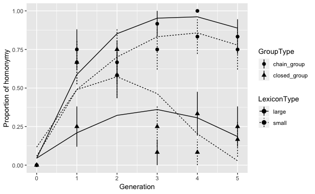

```r
ggplot(df_homonymy, aes(Generation, Word_repetition_binary, shape=GroupType, linetype=LexiconType)) +
  stat_summary(fun.data=mean_se, geom="pointrange") +
  stat_summary(aes(y=fitted(homonymy_second_order_log), linetype=LexiconType),
               fun.y=mean, geom="line") +
  ylab("Proportion of homonymy")
```

```r
dev.print(pdf,'Homonymy Log by Group and Lexicon type - first order model.pdf')
```

# 15 Homonymy (Gen1-5)

Because there’s discontinuity between Generation/Round 0 and 1, redo the analysis in ‘Homonymy’ without Generation/Round 0 (i.e., only Generations 1-5).

## 15.1 Homonymy (Gen1-5): Models

Can’t fit a 3rd order model because there are fewer observations than random effects

```r
homonymy_first_order_1to5 <- lmer(Word_repetition ~
                               ot1*GroupType*LexiconType + (1|Unique_Participant),
                             data=df_homonymy[df_homonymy$Generation != 0, ],
                             control=lmerControl(optimizer = "bobyqa", optCtrl=list(maxfun=1e5)))
homonymy_second_order_1to5 <- lmer(Word_repetition ~
                                (ot1+ot2)*GroupType*LexiconType + (1|Unique_Participant),
                              data=df_homonymy[df_homonymy$Generation != 0, ],
                              control=lmerControl(optimizer = "bobyqa", optCtrl=list(maxfun=1e5)))
summary(homonymy_first_order_1to5)
```

```
Linear mixed model fit by REML. t-tests use Satterthwaite's method ['lmerModLmerTest']
Formula: Word_repetition ~ ot1 * GroupType * LexiconType + (1 | Unique_Participant)
   Data: df_homonymy[df_homonymy$Generation != 0, ]
Control: lmerControl(optimizer = "bobyqa", optCtrl = list(maxfun = 1e+05))

REML criterion at convergence: -529.1

Scaled residuals:
     Min       1Q   Median       3Q      Max
-2.94230 -0.43054 -0.05009  0.28697  2.51129

Random effects:
 Groups             Name        Variance Std.Dev.
 Unique_Participant (Intercept) 0.006764 0.08224
 Residual                       0.001755 0.04189
Number of obs: 240, groups:  Unique_Participant, 144

Fixed effects:
                              Estimate Std. Error         df t value Pr(>|t|)
(Intercept)                  7.564e-02  9.723e-03  1.010e+02   7.779 6.43e-12 ***
ot1                         -2.421e-04  1.369e-02  1.918e+02  -0.018 0.985905
GroupType1                   3.727e-02  9.723e-03  1.010e+02   3.833 0.000220 ***
LexiconType1                -8.972e-03  9.723e-03  1.010e+02  -0.923 0.358304
ot1:GroupType1               4.575e-02  1.369e-02  1.918e+02   3.343 0.000995 ***
ot1:LexiconType1             3.898e-02  1.369e-02  1.918e+02   2.848 0.004879 **
GroupType1:LexiconType1      7.868e-03  9.723e-03  1.010e+02   0.809 0.420310
ot1:GroupType1:LexiconType1 -5.084e-03  1.369e-02  1.918e+02  -0.371 0.710688
---
Signif. codes:  0 ‘***’ 0.001 ‘**’ 0.01 ‘*’ 0.05 ‘.’ 0.1 ‘ ’ 1

Correlation of Fixed Effects:
            (Intr) ot1    GrpTy1 LxcnT1 ot1:GT1 o1:LT1 GT1:LT
ot1         -0.168
GroupType1  -0.578 -0.111
LexiconTyp1  0.000  0.000  0.000
ot1:GrpTyp1 -0.111  0.658 -0.168  0.000
ot1:LxcnTy1  0.000  0.000  0.000 -0.168  0.000
GrpTyp1:LT1  0.000  0.000  0.000 -0.578  0.000  -0.111
ot1:GT1:LT1  0.000  0.000  0.000 -0.111  0.000   0.658 -0.168
```

```r
summary(homonymy_second_order_1to5)
```

```
Linear mixed model fit by REML. t-tests use Satterthwaite's method ['lmerModLmerTest']
Formula: Word_repetition ~ (ot1 + ot2) * GroupType * LexiconType + (1 |
    Unique_Participant)
   Data: df_homonymy[df_homonymy$Generation != 0, ]
Control: lmerControl(optimizer = "bobyqa", optCtrl = list(maxfun = 1e+05))

REML criterion at convergence: -504

Scaled residuals:
     Min       1Q   Median       3Q      Max
-2.86050 -0.46423 -0.05013  0.28079  2.61069

Random effects:
 Groups             Name        Variance Std.Dev.
 Unique_Participant (Intercept) 0.006818 0.08257
 Residual                       0.001782 0.04221
Number of obs: 240, groups:  Unique_Participant, 144

Fixed effects:
                              Estimate Std. Error         df t value Pr(>|t|)
(Intercept)                   0.077976   0.010289 106.214793   7.578 1.38e-11 ***
ot1                          -0.008621   0.018012 189.228986  -0.479 0.632762
ot2                           0.012238   0.016982 189.228986   0.721 0.472012
GroupType1                    0.037582   0.010289 106.214793   3.653 0.000405 ***
LexiconType1                 -0.007451   0.010289 106.214793  -0.724 0.470546
ot1:GroupType1                0.044639   0.018012 189.228986   2.478 0.014078 *
ot2:GroupType1                0.001630   0.016982 189.228986   0.096 0.923625
ot1:LexiconType1              0.033521   0.018012 189.228986   1.861 0.064286 .
ot2:LexiconType1              0.007967   0.016982 189.228986   0.469 0.639490
GroupType1:LexiconType1       0.010257   0.010289 106.214793   0.997 0.321088
ot1:GroupType1:LexiconType1  -0.013651   0.018012 189.228986  -0.758 0.449452
ot2:GroupType1:LexiconType1   0.012514   0.016982 189.228986   0.737 0.462109
---
Signif. codes:  0 ‘***’ 0.001 ‘**’ 0.01 ‘*’ 0.05 ‘.’ 0.1 ‘ ’ 1

Correlation of Fixed Effects:
            (Intr) ot1    ot2    GrpTy1 LxcnT1 ot1:GT1 ot2:GT1 o1:LT1 o2:LT1 GT1:LT
ot1         -0.325
ot2          0.315 -0.645
GroupType1  -0.455 -0.214  0.207
LexiconTyp1  0.000  0.000  0.000  0.000
ot1:GrpTyp1 -0.214  0.657 -0.424 -0.325  0.000
ot2:GrpTyp1  0.207 -0.424  0.657  0.315  0.000 -0.645
ot1:LxcnTy1  0.000  0.000  0.000  0.000 -0.325  0.000   0.000
ot2:LxcnTy1  0.000  0.000  0.000  0.000  0.315  0.000   0.000  -0.645
GrpTyp1:LT1  0.000  0.000  0.000  0.000 -0.455  0.000   0.000  -0.214  0.207
ot1:GT1:LT1  0.000  0.000  0.000  0.000 -0.214  0.000   0.000   0.657 -0.424 -0.325
ot2:GT1:LT1  0.000  0.000  0.000  0.000  0.207  0.000   0.000  -0.424  0.657  0.315
            o1:GT1:
ot1
ot2
GroupType1
LexiconTyp1
ot1:GrpTyp1
ot2:GrpTyp1
ot1:LxcnTy1
ot2:LxcnTy1
GrpTyp1:LT1
ot1:GT1:LT1
ot2:GT1:LT1 -0.645
```

## 15.2 Homonymy (Gen1-5): Model comparison

```r
homonyms_1to5_model.names <- c("Homonymy first order 1 to 5","Homonymy second order 1 to 5")
homonyms_1to5_summ.table <- do.call(rbind, lapply(list(homonymy_first_order_1to5,homonymy_second_order_1to5), broom::glance))
homonyms_1to5_table.cols <- c("df.residual", "deviance", "AIC")
homonyms_1to5_reported.table <- homonyms_1to5_summ.table[homonyms_1to5_table.cols]
names(homonyms_1to5_reported.table) <- c("Resid. Df", "Resid.Dev", "AIC")
homonyms_1to5_reported.table[['dAIC']] <-  with(homonyms_1to5_reported.table, AIC - min(AIC))
homonyms_1to5_reported.table[['AIC_weight']] <- with(homonyms_1to5_reported.table, exp(- 0.5 * dAIC) / sum(exp(- 0.5 * dAIC)))
homonyms_1to5_reported.table$AIC <- NULL
homonyms_1to5_reported.table$AIC_weight <- round(homonyms_1to5_reported.table$AIC_weight, 2)
homonyms_1to5_reported.table$dAIC <- round(homonyms_1to5_reported.table$dAIC, 1)
homonyms_1to5_reported.table$Resid.Dev <- round(homonyms_1to5_reported.table$Resid.Dev, 2)
row.names(homonyms_1to5_reported.table) <- homonyms_1to5_model.names
```

```
Setting row names on a tibble is deprecated.
```

```r
View(homonyms_1to5_reported.table)
anova(homonymy_first_order_1to5,homonymy_second_order_1to5)
```

```
refitting model(s) with ML (instead of REML)
```

```
Data: df_homonymy[df_homonymy$Generation != 0, ]
Models:
homonymy_first_order_1to5: Word_repetition ~ ot1 * GroupType * LexiconType + (1 | Unique_Participant)
homonymy_second_order_1to5: Word_repetition ~ (ot1 + ot2) * GroupType * LexiconType + (1 |
homonymy_second_order_1to5:     Unique_Participant)
                           Df     AIC     BIC logLik deviance  Chisq Chi Df
homonymy_first_order_1to5  10 -568.13 -533.32 294.06  -588.13
homonymy_second_order_1to5 14 -561.50 -512.78 294.75  -589.50 1.3745      4
                           Pr(>Chisq)
homonymy_first_order_1to5
homonymy_second_order_1to5     0.8486
```

```r
sjPlot::tab_df(homonyms_reported.table,
               file="model comparison homonyms_1to5_.doc")
sjPlot::tab_df(round(coef(summary(homonymy_first_order_1to5)),3),file='homonyms_1to5_fixed_effects.doc')
```

## 15.3 Homonymy (Gen1-5): Plots of model fit

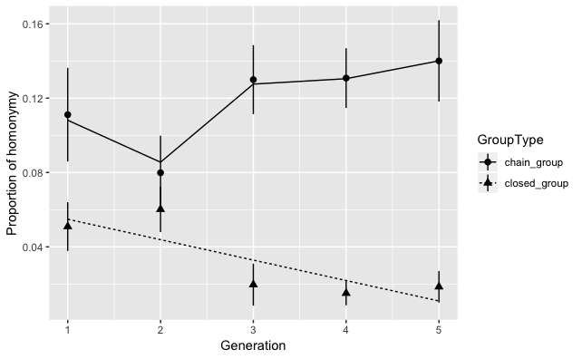

```r
ggplot(df_homonymy[df_homonymy$Generation != 0, ], aes(Generation, Word_repetition, shape=GroupType)) +
  stat_summary(fun.data=mean_se, geom="pointrange") +
  stat_summary(aes(y=fitted(homonymy_first_order_1to5), linetype=GroupType),
               fun.y=mean, geom="line") +
  ylab("Proportion of homonymy")
```

```r
dev.print(pdf,'Homonymy 1to5 by group type - first order model.pdf')
```

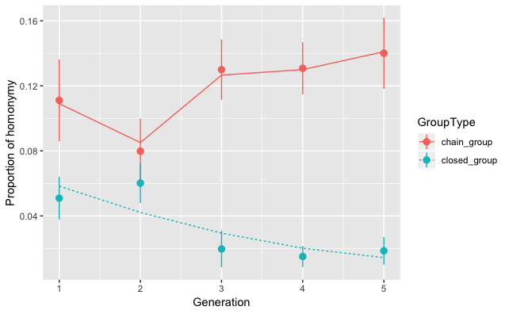

```r
ggplot(df_homonymy[df_homonymy$Generation != 0, ], aes(Generation, Word_repetition, color=GroupType)) +
  stat_summary(fun.data=mean_se, geom="pointrange") +
  stat_summary(aes(y=fitted(homonymy_second_order_1to5), linetype=GroupType),
               fun.y=mean, geom="line") +
  ylab("Proportion of homonymy")
```

```r
dev.print(pdf,'Homonymy 1to5  by group type - second order model.pdf')
```

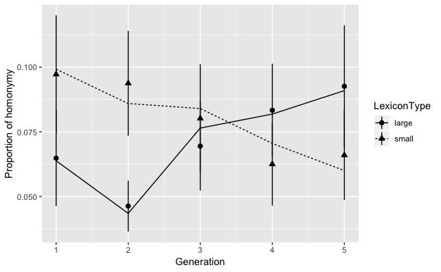

```r
ggplot(df_homonymy[df_homonymy$Generation != 0, ], aes(Generation, Word_repetition, shape=LexiconType)) +
  stat_summary(fun.data=mean_se, geom="pointrange") +
  stat_summary(aes(y=fitted(homonymy_first_order_1to5), linetype=LexiconType),
               fun.y=mean, geom="line") +
  ylab("Proportion of homonymy")
```

```r
dev.print(pdf,'Homonymy 1to5 by lexicon type - first order model.pdf')
```

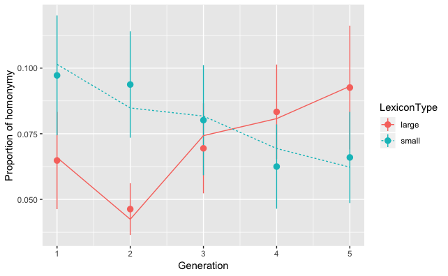

```r
ggplot(df_homonymy[df_homonymy$Generation != 0, ], aes(Generation, Word_repetition, color=LexiconType)) +
  stat_summary(fun.data=mean_se, geom="pointrange") +
  stat_summary(aes(y=fitted(homonymy_second_order_1to5), linetype=LexiconType),
               fun.y=mean, geom="line") +
  ylab("Proportion of homonymy")
```

```r
dev.print(pdf,'Homonymy 1to5  by lexicon type - second order model.pdf')
```

# 16 Homonymy and sound repetition

Two related questions: 1) Is sound repetition more prevelant among homonyms? (i.e., Is sound repetition driven by homonymy?) 2) Do we see the same pattern of sound repetition increase when we look only at non-homonyms?

```r
# This bit of script identifies homonyms in each lexicon
# Identify duplicates within every subset of words
df_u = ddply(df_director, c("GroupType", "LexiconType", "GroupNumber", "Generation", "Unique_language", "Pair", "Unique_Participant"), summarise, dup = duplicated(TypedLabel))
# Paste that information back to the main dateframe
df_u2 = cbind(df_director, df_u$dup)
# List up words that have copies (i.e., homonyms)
homs = unique(subset(df_u2, df_u$dup == 'TRUE'))
# Create variable 'homonym'
df_director = merge(df_director, homs, all.x=TRUE)
colnames(df_director)[colnames(df_director)=="df_u$dup"] <- "homonym"
df_director$homonym[is.na(df_director$homonym)] <- 0
# Create a subset without homonyms
NoHoms = subset(df_director, homonym == 0)
```

## 16.1 Impact of homonymy on sound repetition

Is sound repetition more prevelant among homonyms? The analysis shows no effects of homonymy on CVC. So the answer is NO.

```r
CVC_hom_third_order <- glmer(ConsonantRepetition ~ #maximal random effect structure, up to cubic term
                  (ot1+ot2+ot3) * GroupType * LexiconType * homonym + (1|Unique_Participant) + (1|Meaning),
                  data=df_director, family=binomial,
                  control=glmerControl(optimizer = "bobyqa", optCtrl=list(maxfun=1e5)))
CVC_hom_second_order <- glmer(ConsonantRepetition ~ #maximal random effect structure, up to quadratic term
                    (ot1+ot2) * GroupType * LexiconType * homonym + (1|Unique_Participant) + (1|Meaning),
                   data=df_director, family=binomial,
                   control=glmerControl(optimizer = "bobyqa", optCtrl=list(maxfun=1e5)))
CVC_hom_first_order <- glmer(ConsonantRepetition ~ #maximal random effect structure, up to linear term
                    ot1 * GroupType * LexiconType * homonym+ (1|Unique_Participant) + (1|Meaning),
                    data=df_director, family=binomial,
                    control=glmerControl(optimizer = "bobyqa", optCtrl=list(maxfun=1e5)))
summary(CVC_hom_third_order)
```

```
Generalized linear mixed model fit by maximum likelihood (Laplace Approximation) [
glmerMod]
 Family: binomial  ( logit )
Formula: ConsonantRepetition ~ (ot1 + ot2 + ot3) * GroupType * LexiconType *
    homonym + (1 | Unique_Participant) + (1 | Meaning)
   Data: df_director
Control: glmerControl(optimizer = "bobyqa", optCtrl = list(maxfun = 1e+05))

     AIC      BIC   logLik deviance df.resid
  5027.5   5243.9  -2479.8   4959.5     4261

Scaled residuals:
    Min      1Q  Median      3Q     Max
-2.1271 -0.6352 -0.4459  0.8407  4.1626

Random effects:
 Groups             Name        Variance Std.Dev.
 Unique_Participant (Intercept) 0.7072   0.8410
 Meaning            (Intercept) 0.2423   0.4922
Number of obs: 4295, groups:  Unique_Participant, 156; Meaning, 18

Fixed effects:
                                     Estimate Std. Error z value Pr(>|z|)
(Intercept)                         -0.825474   0.152960  -5.397 6.79e-08 ***
ot1                                  0.317808   0.186654   1.703  0.08863 .
ot2                                  0.151074   0.182174   0.829  0.40695
ot3                                 -0.238893   0.157368  -1.518  0.12900
GroupType1                           0.149625   0.090299   1.657  0.09752 .
LexiconType1                        -0.092306   0.099307  -0.929  0.35263
homonym                             -0.085535   0.116027  -0.737  0.46100
ot1:GroupType1                       0.433898   0.146424   2.963  0.00304 **
ot2:GroupType1                       0.037118   0.145987   0.254  0.79930
ot3:GroupType1                      -0.054982   0.138576  -0.397  0.69154
ot1:LexiconType1                    -0.211805   0.186717  -1.134  0.25664
ot2:LexiconType1                    -0.045818   0.182003  -0.252  0.80124
ot3:LexiconType1                    -0.006802   0.157558  -0.043  0.96557
GroupType1:LexiconType1              0.025304   0.090318   0.280  0.77935
ot1:homonym                         -0.188607   0.280900  -0.671  0.50194
ot2:homonym                         -0.033660   0.272716  -0.123  0.90177
ot3:homonym                          0.257021   0.289395   0.888  0.37447
GroupType1:homonym                  -0.028434   0.121388  -0.234  0.81480
LexiconType1:homonym                 0.135380   0.116223   1.165  0.24409
ot1:GroupType1:LexiconType1         -0.068705   0.146339  -0.469  0.63872
ot2:GroupType1:LexiconType1         -0.063946   0.145843  -0.438  0.66105
ot3:GroupType1:LexiconType1         -0.028869   0.138561  -0.208  0.83496
ot1:GroupType1:homonym              -0.136702   0.309209  -0.442  0.65842
ot2:GroupType1:homonym               0.153424   0.295459   0.519  0.60357
ot3:GroupType1:homonym              -0.033174   0.299554  -0.111  0.91182
ot1:LexiconType1:homonym            -0.418409   0.281860  -1.484  0.13769
ot2:LexiconType1:homonym            -0.371891   0.273201  -1.361  0.17344
ot3:LexiconType1:homonym            -0.355473   0.290725  -1.223  0.22144
GroupType1:LexiconType1:homonym      0.024307   0.121698   0.200  0.84169
ot1:GroupType1:LexiconType1:homonym -0.001871   0.309185  -0.006  0.99517
ot2:GroupType1:LexiconType1:homonym -0.164895   0.295617  -0.558  0.57698
ot3:GroupType1:LexiconType1:homonym  0.132556   0.299933   0.442  0.65852
---
Signif. codes:  0 ‘***’ 0.001 ‘**’ 0.01 ‘*’ 0.05 ‘.’ 0.1 ‘ ’ 1
```

```
Correlation matrix not shown by default, as p = 32 > 12.
Use print(x, correlation=TRUE)  or
    vcov(x)        if you need it
```

```r
summary(CVC_hom_second_order)
```

```
Generalized linear mixed model fit by maximum likelihood (Laplace Approximation) [
glmerMod]
 Family: binomial  ( logit )
Formula: ConsonantRepetition ~ (ot1 + ot2) * GroupType * LexiconType *
    homonym + (1 | Unique_Participant) + (1 | Meaning)
   Data: df_director
Control: glmerControl(optimizer = "bobyqa", optCtrl = list(maxfun = 1e+05))

     AIC      BIC   logLik deviance df.resid
  5015.8   5181.3  -2481.9   4963.8     4269

Scaled residuals:
    Min      1Q  Median      3Q     Max
-2.1020 -0.6349 -0.4471  0.8397  4.2169

Random effects:
 Groups             Name        Variance Std.Dev.
 Unique_Participant (Intercept) 0.7258   0.8519
 Meaning            (Intercept) 0.2419   0.4918
Number of obs: 4295, groups:  Unique_Participant, 156; Meaning, 18

Fixed effects:
                                     Estimate Std. Error z value Pr(>|z|)
(Intercept)                         -0.841727   0.152632  -5.515 3.49e-08 ***
ot1                                  0.410149   0.165835   2.473  0.01339 *
ot2                                  0.057394   0.161529   0.355  0.72235
GroupType1                           0.142524   0.088324   1.614  0.10660
LexiconType1                        -0.091506   0.098845  -0.926  0.35457
homonym                             -0.106521   0.111032  -0.959  0.33737
ot1:GroupType1                       0.399793   0.143450   2.787  0.00532 **
ot2:GroupType1                       0.066388   0.142726   0.465  0.64183
ot1:LexiconType1                    -0.180336   0.165727  -1.088  0.27653
ot2:LexiconType1                    -0.078379   0.161539  -0.485  0.62753
GroupType1:LexiconType1              0.009657   0.088303   0.109  0.91292
ot1:homonym                         -0.159999   0.278710  -0.574  0.56592
ot2:homonym                         -0.012163   0.263805  -0.046  0.96323
GroupType1:homonym                   0.001800   0.117069   0.015  0.98774
LexiconType1:homonym                 0.168173   0.111496   1.508  0.13147
ot1:GroupType1:LexiconType1         -0.061823   0.143392  -0.431  0.66636
ot2:GroupType1:LexiconType1         -0.065543   0.142445  -0.460  0.64542
ot1:GroupType1:homonym              -0.116411   0.306709  -0.380  0.70428
ot2:GroupType1:homonym               0.111697   0.287231   0.389  0.69737
ot1:LexiconType1:homonym            -0.440359   0.279574  -1.575  0.11523
ot2:LexiconType1:homonym            -0.304301   0.264081  -1.152  0.24920
GroupType1:LexiconType1:homonym      0.028337   0.117529   0.241  0.80947
ot1:GroupType1:LexiconType1:homonym -0.016147   0.306854  -0.053  0.95803
ot2:GroupType1:LexiconType1:homonym -0.177081   0.287446  -0.616  0.53786
---
Signif. codes:  0 ‘***’ 0.001 ‘**’ 0.01 ‘*’ 0.05 ‘.’ 0.1 ‘ ’ 1
```

```
Correlation matrix not shown by default, as p = 24 > 12.
Use print(x, correlation=TRUE)  or
    vcov(x)        if you need it
```

```r
summary(CVC_hom_first_order)
```

```
Generalized linear mixed model fit by maximum likelihood (Laplace Approximation) [
glmerMod]
 Family: binomial  ( logit )
Formula: ConsonantRepetition ~ ot1 * GroupType * LexiconType * homonym +
    (1 | Unique_Participant) + (1 | Meaning)
   Data: df_director
Control: glmerControl(optimizer = "bobyqa", optCtrl = list(maxfun = 1e+05))

     AIC      BIC   logLik deviance df.resid
  5002.8   5117.4  -2483.4   4966.8     4277

Scaled residuals:
    Min      1Q  Median      3Q     Max
-2.1327 -0.6353 -0.4481  0.8387  4.2950

Random effects:
 Groups             Name        Variance Std.Dev.
 Unique_Participant (Intercept) 0.7386   0.8594
 Meaning            (Intercept) 0.2415   0.4914
Number of obs: 4295, groups:  Unique_Participant, 156; Meaning, 18

Fixed effects:
                                      Estimate Std. Error z value Pr(>|z|)
(Intercept)                         -0.8585352  0.1514597  -5.668 1.44e-08 ***
ot1                                  0.4104732  0.1486603   2.761  0.00576 **
GroupType1                           0.1568543  0.0842311   1.862  0.06258 .
LexiconType1                        -0.0739236  0.0969545  -0.762  0.44579
homonym                             -0.0972608  0.1079764  -0.901  0.36772
ot1:GroupType1                       0.4025634  0.1390413   2.895  0.00379 **
ot1:LexiconType1                    -0.2100158  0.1486132  -1.413  0.15761
GroupType1:LexiconType1             -0.0009838  0.0842120  -0.012  0.99068
ot1:homonym                         -0.1466010  0.2542884  -0.577  0.56427
GroupType1:homonym                  -0.0086424  0.1132728  -0.076  0.93918
LexiconType1:homonym                 0.1671507  0.1084760   1.541  0.12334
ot1:GroupType1:LexiconType1         -0.0524876  0.1389927  -0.378  0.70571
ot1:GroupType1:homonym              -0.1923187  0.2901077  -0.663  0.50738
ot1:LexiconType1:homonym            -0.3017775  0.2558049  -1.180  0.23811
GroupType1:LexiconType1:homonym     -0.0003820  0.1138068  -0.003  0.99732
ot1:GroupType1:LexiconType1:homonym  0.0712176  0.2905785   0.245  0.80639
---
Signif. codes:  0 ‘***’ 0.001 ‘**’ 0.01 ‘*’ 0.05 ‘.’ 0.1 ‘ ’ 1
```

```
Correlation matrix not shown by default, as p = 16 > 12.
Use print(x, correlation=TRUE)  or
    vcov(x)        if you need it
```

```r
CVC_hom_model.names <- c("CVC_hom first order","CVC_hom second order","CVC_hom third order")
CVC_hom_summ.table <- do.call(rbind, lapply(list(CVC_hom_first_order,CVC_hom_second_order,CVC_hom_third_order), broom::glance))
CVC_hom_table.cols <- c("df.residual", "deviance", "AIC")
CVC_hom_reported.table <- CVC_hom_summ.table[CVC_hom_table.cols]
names(CVC_hom_reported.table) <- c("Resid.Df", "Resid.Dev", "AIC")
CVC_hom_reported.table[['dAIC']] <-  with(CVC_hom_reported.table, AIC - min(AIC))
CVC_hom_reported.table[['AIC_weight']] <- with(CVC_hom_reported.table, exp(- 0.5 * dAIC) / sum(exp(- 0.5 * dAIC)))
CVC_hom_reported.table$AIC <- NULL
CVC_hom_reported.table$AIC_weight <- round(CVC_hom_reported.table$AIC_weight, 2)
CVC_hom_reported.table$dAIC <- round(CVC_hom_reported.table$dAIC, 1)
CVC_hom_reported.table$Resid.Dev <- round(CVC_hom_reported.table$Resid.Dev, 2)
row.names(CVC_hom_reported.table) <- CVC_hom_model.names
```

```
Setting row names on a tibble is deprecated.
```

```r
View(CVC_hom_reported.table)
sjPlot::tab_df(CVC_hom_reported.table,
       file="model comparison CVC_hom.doc")
```